# SIL Project

Victoria Grosu

# Dataset

This particular component focuses on collecting detailed information from one randomly selected adult per participating household. The topics span a wide array of domains, including physical and mental health, chronic conditions, access to healthcare, and health-related behaviors.

The dataset is substantial, comprising 29,522 rows and 647 columns. Each row corresponds to an individual respondent, while the columns represent responses to various survey items. Owing to the survey’s design, many columns are conditionally populated. For instance, respondents who report a diabetes diagnosis are subsequently queried about insulin usage and age at diagnosis. This conditional logic results in numerous columns being sparsely populated, as not all questions apply universally.

```r
data <- read.csv("adult23.csv", stringsAsFactors = FALSE)

data[] <- lapply(data, function(col) factor(as.character(col)))


dataset_dimensions <- dim(data)
num_rows <- dataset_dimensions[1]
num_cols <- dataset_dimensions[2]

na_counts <- colSums(is.na(data))
num_columns_with_na <- sum(na_counts > 0)
num_columns_complete <- sum(na_counts == 0)


cat("The dataset contains", num_rows, "rows and", num_cols, "columns.\n")
```

```
## The dataset contains 29522 rows and 647 columns.
```

```r
cat(num_columns_with_na, "columns contain at least one missing value,\n")
```

```
## 440 columns contain at least one missing value,
```

```r
cat("while", num_columns_complete, "columns are fully populated.\n")
```

```
## while 207 columns are fully populated.
```

```r
mean_na_proportion <- mean(na_counts / num_rows)
cat("On average,", round(mean_na_proportion * 100, 2), "% of entries per column are missing.\n")
```

```
## On average, 52.06 % of entries per column are missing.
```

## Preliminary Dataset Analysis

The dataset `adult23.csv` contains **29,522 rows** and **647 columns**.

To evaluate data quality, we analyzed the presence of missing values:

- **440 columns** (≈ 68%) contain at least one missing value.
- **207 columns** (≈ 32%) are fully populated with no missing values.
- On average, **52.06% of the entries per column are missing**, highlighting a substantial amount of incomplete data.

This degree of missingness suggests the need for a proper handling strategy prior to any modeling or deeper exploration. **Imputation**, **column filtering**, or **dimensionality reduction** techniques should be considered.

## Variable Filtering Based on Semantic and Structural Criteria

Several variables in the dataset were removed to enhance predictive performance and reduce noise. The filtering was based on three main principles:

### 1. Technical or Documentation-Only Fields

These include identifiers and metadata fields that do not convey predictive information:

- `RECTYPE`, `SRVY_YR`, `HHX`, `WTFA_A` (Identifiers)
- `PSTRAT`, `PPSU` (Survey design variables)
- `HHRESPSA_FLG`, `ASTATNEW`, `HHSTAT_A`, `AVAIL_A` (Administrative or respondent status fields)

### 2. Low-Information Columns

Variables were removed if:

- All values are identical (constant).
- All values are unique (typically IDs or free-text inputs).

### 3. Survey Skip Patterns

The dataset follows a conditional survey logic, where follow-up questions are asked only if the previous answer was “Yes”.  
Such patterns introduce **structured missingness**.

Only variables with **meaningful variability** and **potential predictive power** were retained.

```r
cols_to_remove <- c("RECTYPE", "SRVY_YR", "HHX", "WTFA_A", "PSTRAT", "PPSU",
                    "HHRESPSA_FLG", "ASTATNEW", "HHSTAT_A", "AVAIL_A")

unique_or_all_diff <- sapply(data, function(col) {
  n_unique <- length(unique(col))
  n_total <- length(col)
  return(n_unique == 1 || n_unique == n_total)
})

cols_low_info <- names(unique_or_all_diff[unique_or_all_diff])

all_cols_to_remove <- unique(c(cols_to_remove, cols_low_info))
all_cols_to_remove <- all_cols_to_remove[all_cols_to_remove %in% names(data)]

data <- data[, !(names(data) %in% all_cols_to_remove)]

cat("Removed columns:\n")
```

```
## Removed columns:
```

```r
print(all_cols_to_remove)
```

```
##  [1] "RECTYPE"      "SRVY_YR"      "HHX"          "WTFA_A"       "PSTRAT"
##  [6] "PPSU"         "HHRESPSA_FLG" "ASTATNEW"     "HHSTAT_A"     "AVAIL_A"
## [11] "OGFLG_A"      "OPFLG_A"      "CHFLG_A"      "IMPNUM_A"
```

```r
cat("\nTotal columns removed:", length(all_cols_to_remove), "\n")
```

```
##
## Total columns removed: 14
```

```r
cat("Total remaining columns:", ncol(data), "\n")
```

```
## Total remaining columns: 633
```

## Analysis of Numerical Variables with Missing Values

To better understand missing data patterns in numerical features, we cross-referenced the variable list from `column_analysis.csv` with the actual dataset `data`.

The table below shows each numerical column and its corresponding number of missing entries:

```r
column_analysis <- read.csv("column_analysis.csv")
head(column_analysis)
```

```
##   Column.Name Null.Count Null.Percentage Not.Null.Percentage Data.Type Mode
## 1      URBRRL          0         0.00000             100.00%     int64    3
## 2    RATCAT_A          0         0.00000             100.00%     int64   14
## 3  INCTCFLG_A          0         0.00000             100.00%     int64    0
## 4 IMPINCFLG_A          0         0.00000             100.00%     int64    0
## 5 LANGSPECR_A      25473        86.28480              13.72%   float64  1.0
## 6   LANGSOC_A      25549        86.54224              13.46%   float64  1.0
##         Mean Unique.Count                                Unique.Values.Summary
## 1 2.31711944            4                                         [3, 4, 1, 2]
## 2 9.66675699           14 {'Examples': [4, 8, 14, 10, 5], 'Type': 'Numerical'}
## 3 0.04166384            2                                               [0, 1]
## 4 0.37372129            3                                            [0, 1, 2]
## 5 1.45344530            5                            [2.0, 1.0, 7.0, 9.0, 8.0]
## 6 1.48099673            5                            [1.0, 2.0, 9.0, 7.0, 8.0]
##   Column.Type
## 1 Categorical
## 2   Numerical
## 3 Categorical
## 4 Categorical
## 5 Categorical
## 6 Categorical
```

```r
numerical_columns <- column_analysis[column_analysis$Column.Type == "Numerical", ]
numerical_columns_in_data <- numerical_columns[numerical_columns$Column.Name %in% names(data), ]
numerical_columns_sorted <- numerical_columns_in_data[order(-numerical_columns_in_data$Null.Count), ]
print(numerical_columns_sorted[, c("Column.Name", "Null.Count")])
```

```
##      Column.Name Null.Count
## 123 MOUTHAGETC_A      29509
## 131 ESOPHAGETC_A      29505
## 127 LIVERAGETC_A      29503
## 119 RECTUAGETC_A      29502
## 121 PANCRAGETC_A      29502
## 115 STOMAAGETC_A      29501
## 136  BONEAGETC_A      29501
## 137 BLOODAGETC_A      29496
## 135 BRAINAGETC_A      29490
## 114 THROAAGETC_A      29480
## 128 LEUKEAGETC_A      29461
## 110 HDNCKAGETC_A      29458
## 122 OVARYAGETC_A      29448
## 138 BLADDAGETC_A      29421
```

[output cut: 54 more lines]

## Filtering Valid Age Range (`AGEP_A`)

The variable `AGEP_A` represents the age of the sampled adult (SA), top-coded for public use.  
According to the NHIS documentation, this variable uses specific codes for non-informative responses:

- `85`: 85+ years (valid age, but top-coded)
- `97`: Refused
- `98`: Not Ascertained
- `99`: Don’t Know

To retain only the responses representing **actual ages**, we filtered the dataset to include only values between **18 and 84** (inclusive).

This allows us to avoid mixing genuine observations with placeholders that do not correspond to real, interpretable values.  
The filtering enhances **data integrity** and prevents **misleading interpretations** during analysis.

```r
data$AGEP_A <- as.numeric(as.character(data$AGEP_A))
data <- subset(data, AGEP_A >= 18 & AGEP_A <= 84)

summary(data$AGEP_A)
```

```
##    Min. 1st Qu.  Median    Mean 3rd Qu.    Max.
##   18.00   36.00   53.00   51.92   67.00   84.00
```

### Age Distribution After Filtering

The following histogram shows the distribution of the `AGEP_A` variable after filtering values to the 18–84 age range. This ensures that only meaningful and valid ages are retained, excluding placeholder codes like 85 (top-coded), 97, 98, and 99.

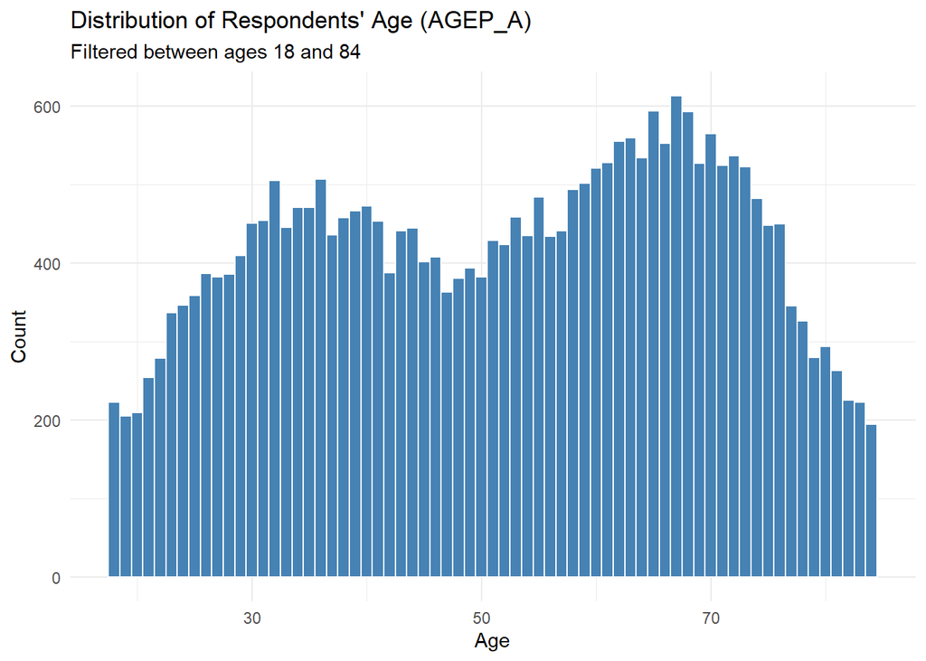

```r
library(ggplot2)

ggplot(data, aes(x = AGEP_A)) +
  geom_histogram(binwidth = 1, fill = "steelblue", color = "white") +
  labs(
    title = "Distribution of Respondents' Age (AGEP_A)",
    subtitle = "Filtered between ages 18 and 84",
    x = "Age",
    y = "Count"
  ) +
  theme_minimal()
```

### Age-Based Conditional Variables

We identified a group of variables whose availability depends on the respondent’s age. Specifically, the following variables are only populated when `AGEP_A` is between **40 and 85 years**:

- `COLOGUARD1_A`: Ever had Cologuard
- `FITHEV1_A`: Ever had home blood stool test or FIT
- `CTCOLEV1_A`: Ever had a colonography or virtual colonoscopy
- `COLORECTEV_A`: Ever had a colonoscopy or sigmoidoscopy
- `ASPMEDEV_A`: Told to take low-dose aspirin

To verify this, we created confusion matrices comparing the presence of `NA` values in each variable with whether the individual’s age falls in the 40–85 range.

**Summary of results:** - For all variables, individuals < 40 or > 85 always have `NA`. - Individuals aged 40–85 always have valid, non-missing responses.

This shows that these variables follow a **conditional skip pattern** in the survey design. Their missingness is **structural**, not random, and should be interpreted accordingly in modeling or imputation strategies.

```r
age_vars <- c("COLOGUARD1_A", "FITHEV1_A", "CTCOLEV1_A", "COLORECTEV_A", "ASPMEDEV_A")
valid_age <- data$AGEP_A >= 40 & data$AGEP_A <= 85

for (var in age_vars) {
  var_na <- is.na(data[[var]])

  cm <- table(
    `Missing in variable` = ifelse(var_na, "NA", "Not NA"),
    `Age in range 40–85` = ifelse(valid_age, "Yes", "No")
  )

  cat(sprintf("\nConfusion matrix for %s:\n", var))
  print(cm)
}
```

```
##
## Confusion matrix for COLOGUARD1_A:
##                    Age in range 40–85
## Missing in variable    No   Yes
##              NA      8449     0
##              Not NA     0 19897
##
## Confusion matrix for FITHEV1_A:
##                    Age in range 40–85
## Missing in variable    No   Yes
##              NA      8449     0
##              Not NA     0 19897
##
## Confusion matrix for CTCOLEV1_A:
##                    Age in range 40–85
## Missing in variable    No   Yes
##              NA      8449     0
##              Not NA     0 19897
##
## Confusion matrix for COLORECTEV_A:
##                    Age in range 40–85
## Missing in variable    No   Yes
##              NA      8449     0
##              Not NA     0 19897
##
## Confusion matrix for ASPMEDEV_A:
##                    Age in range 40–85
## Missing in variable    No   Yes
##              NA      8449     0
##              Not NA     0 19897
```

```r
cols_to_remove <- c("COLOGUARD1_A", "FITHEV1_A", "CTCOLEV1_A", "COLORECTEV_A", "ASPMEDEV_A")
data <- data[, !names(data) %in% cols_to_remove]
new_dims <- dim(data)
```

## Weight Variable (`WEIGHTLBTC_A`)

The variable `WEIGHTLBTC_A` captures weight in pounds, without shoes.

### Cleaning:

1. Convert the variable to numeric.
2. Remove values outside the 100–299 lb range.
3. Convert from pounds to kilograms using: `kg = lb × 0.453592`

```r
data$WEIGHTLBTC_A <- as.numeric(as.character(data$WEIGHTLBTC_A))
data <- subset(data, WEIGHTLBTC_A >= 100 & WEIGHTLBTC_A <= 299)
data$WEIGHTLBTC_A <- data$WEIGHTLBTC_A * 0.453592
summary(data$WEIGHTLBTC_A)
```

```
##    Min. 1st Qu.  Median    Mean 3rd Qu.    Max.
##   45.36   68.04   79.38   80.90   91.63  135.62
```

## Height Variable (`HEIGHTTC_A`)

The variable `HEIGHTTC_A` represents height in inches, without shoes.  
Valid values range from **59 to 76 inches**.

### Cleaning:

1. Convert the variable to numeric.
2. Filter values between 59 and 76 inches.
3. Convert to meters using: `m = inch × 0.0254`

```r
data$HEIGHTTC_A <- as.numeric(as.character(data$HEIGHTTC_A))
data <- subset(data, HEIGHTTC_A >= 59 & HEIGHTTC_A <= 76)
data$HEIGHTTC_A <- data$HEIGHTTC_A * 0.0254
summary(data$HEIGHTTC_A)
```

```
##    Min. 1st Qu.  Median    Mean 3rd Qu.    Max.
##   1.499   1.626   1.702   1.695   1.778   1.930
```

## Poverty Ratio (`POVRATTC_A`)

The variable `POVRATTC_A` indicates the ratio of a family’s income to the poverty threshold. According to the documentation, all values above 11.00 are **top-coded** and recorded as `11.00`, concealing their true (higher) value.

### Why it matters:

- The value `11.00` is not exact, but rather a lower bound for high-income households.
- Using `POVRATTC_A` as-is would flatten variability and potentially mislead predictive models.

### Cleaning:

We performed the following steps:

1. Converted `POVRATTC_A` to numeric.
2. Created a binary indicator `POVRATTC_topcoded`, set to 1 if the value is 11.00 (top-coded), 0 otherwise.

```r
data <- data %>%
  mutate(
    POVRATTC_A = as.numeric(as.character(POVRATTC_A)),
    POVRATTC_topcoded = if_else(POVRATTC_A == 11.00, 1, 0)
  )


data %>%
  select(POVRATTC_A, POVRATTC_topcoded) %>%
  head()
```

```
##   POVRATTC_A POVRATTC_topcoded
## 1       1.01                 0
## 2       2.49                 0
## 3       6.73                 0
## 4       3.43                 0
## 5       1.27                 0
## 6       9.18                 0
```

```r
summary(data$POVRATTC_A)
```

```
##    Min. 1st Qu.  Median    Mean 3rd Qu.    Max.
##   0.000   1.880   3.390   4.209   5.720  11.000
```

```r
table(data$POVRATTC_topcoded)
```

```
##
##     0     1
## 24210  1712
```

```r
prop.table(table(data$POVRATTC_topcoded))
```

```
##
##          0          1
## 0.93395571 0.06604429
```

### Removing Top-Coded Poverty Ratio Cases

To simplify the analysis and avoid ambiguity due to unknown income levels above 11, we decided to remove these cases:

```r
data$POVRATTC_A <- as.numeric(as.character(data$POVRATTC_A))
data <- subset(data, POVRATTC_A < 11.00)
data$POVRATTC_topcoded <-NULL
```

## Mother-Daughter Variable Structure

In structured survey data, some variables are only asked conditionally based on a prior “mother” question. For example:

- If the respondent answers **“1” (Yes)** to the mother question, then the daughter question is asked.
- Otherwise, the daughter question is skipped, and its value is **NA**.

We verified this structure by checking that daughter variables are only non-missing when the corresponding mother variable equals `"1"`, and missing otherwise.

```r
mother_daughter_matches <- find_strict_mother_daughter(data)
```

```
##          mother      daughter
## 1    FSNAP12M_A    FSNAP30D_A
## 2   SCHCURENR_A  SCHDYMSSTC_A
## 3       AFVET_A      VAHOSP_A
## 4       AFVET_A      VADISB_A
## 5       AFVET_A    AFVETTRN_A
## 6  HRJBEXP12M_A  HRJBEXP4HR_A
## 7  HRVLOUD12M_A   HRVLDPROT_A
## 8    HRFIREEV_A   HRFIRE12M_A
## 9    HRFIREEV_A  HRFIRETOTR_A
## 10  HRLOUDJOB_A HRLOUDJB12M_A
## 11  HRLOUDJOB_A  HRLOUDJBYR_A
## 12 HRTINNITUS_A  HRTINMEDSP_A
## 13 HRTINNITUS_A   HRTINPROB_A
## 14 HRTINNITUS_A    HRTINLNG_A
```

[output cut: 80 more lines]

## Conditional Missingness: Dizziness Module

In this project, we observed that some variables have missing values (`NA`) that are **not missing at random (NMAR)**, but are the direct consequence of **survey logic**.

One example is the variable `BALDIZZ_A`, which asks whether the respondent experienced dizziness or balance problems in the past 12 months.

Only if the respondent answers `"1" (Yes)`, the survey proceeds with the following follow-up questions:

- `BALDHP_A`: Whether the person saw a healthcare provider for the dizziness problem.
- `BALDPROB_A`: How severe the problem was.

These “daughter variables” are therefore **structurally missing** for all respondents who answered anything other than `"Yes"` to `BALDIZZ_A`.

### Logical Validation

To confirm this, we used confusion matrices to verify that:

- When `BALDIZZ_A == 1`, the daughter variables are filled (not `NA`);
- In all other cases (`2`, `7`, `8`, `9`), the daughter variables are `NA`.

This validates the **deterministic nature of the missing data** and justifies **not imputing** these values or treating them as random. Instead, we chose to remove these variables from the modeling dataset.

```r
trigger <- "BALDIZZ_A"
value_filter = c(1)

matched_targets <- find_dependent_targets(data, trigger_var = "BALDIZZ_A", value_filter = value_filter)
```

```
##
##  Dependent target columns found:
## [1] "BALDHP_A"   "BALDPROB_A"
```

```r
if (!is.null(matched_targets)) {
  for (target in matched_targets) {
    confusion_value_vs_na(data, trigger_var = "BALDIZZ_A", target_var = target, value_filter = value_filter)
  }
}
```

```
##
## Confusion Matrix ( BALDHP_A ~ is.na vs BALDIZZ_A in 1 ):
##                TargetIsNA
## TriggerInFilter FALSE  TRUE
##           FALSE     0 19164
##           TRUE   5046     0
##
## Confusion Matrix ( BALDPROB_A ~ is.na vs BALDIZZ_A in 1 ):
##                TargetIsNA
## TriggerInFilter FALSE  TRUE
##           FALSE     0 19164
##           TRUE   5046     0
```

## Target Variable: DIBEV_A (Ever Had Diabetes)

The variable `DIBEV_A` is our target for prediction. It records whether a respondent has ever been told by a medical professional that they have diabetes (excluding gestational and prediabetes).

**Value breakdown:**

- `1` → Yes (has diabetes)
- `2` → No
- `7`, `8`, `9` → Refused / Not Ascertained / Don’t Know

We treat `DIBEV_A == 1` as the positive class, and explore other variables that are conditionally asked based on this response.

### Conditional Variables Linked to Diabetes Diagnosis (DIBEV_A)

We analyzed the logical structure of the questionnaire to identify variables that are conditionally shown based on the response to `DIBEV_A`, which asks whether the respondent has ever been diagnosed with diabetes.

Using a custom function, we detected the following daughter variables:

- `DIBAGETC_A`: Age when first diagnosed
- `DIFYRSTC1_A`: Years since diagnosis
- `DIBA1CLAST_A`: Last A1C test result
- `DIBTYPE_A`: Type of diabetes
- `DIBLAST1_A`: Time since last diabetes care visit

### Structural Validation

We validated this using confusion matrices comparing `DIBEV_A` with the NA pattern of each dependent variable:

This confirms that NA values in these variables are **not random**, but the result of **survey logic**, and should not be imputed or treated as unknown.

```r
trigger <- "DIBEV_A"
value_filter = c(1)

matched_targets <- find_dependent_targets(data, trigger_var = "DIBEV_A", value_filter = value_filter)
```

```
##
##  Dependent target columns found:
## [1] "DIBAGETC_A"   "DIFYRSTC1_A"  "DIBA1CLAST_A" "DIBTYPE_A"
```

```r
if (!is.null(matched_targets)) {
  for (target in matched_targets) {
    confusion_value_vs_na(data, trigger_var = "DIBEV_A", target_var = target, value_filter = value_filter)
  }
}
```

```
##
## Confusion Matrix ( DIBAGETC_A ~ is.na vs DIBEV_A in 1 ):
##                TargetIsNA
## TriggerInFilter FALSE  TRUE
##           FALSE     0 21556
##           TRUE   2654     0
##
## Confusion Matrix ( DIFYRSTC1_A ~ is.na vs DIBEV_A in 1 ):
##                TargetIsNA
## TriggerInFilter FALSE  TRUE
##           FALSE     0 21556
##           TRUE   2654     0
##
## Confusion Matrix ( DIBA1CLAST_A ~ is.na vs DIBEV_A in 1 ):
##                TargetIsNA
## TriggerInFilter FALSE  TRUE
##           FALSE     0 21556
##           TRUE   2654     0
##
## Confusion Matrix ( DIBTYPE_A ~ is.na vs DIBEV_A in 1 ):
##                TargetIsNA
## TriggerInFilter FALSE  TRUE
##           FALSE     0 21556
##           TRUE   2654     0
```

```r
trigger <- "DIBEV_A"
value_filter = c(2,7,9)

matched_targets <- find_dependent_targets(data, trigger_var = "DIBEV_A", value_filter = value_filter)
```

```
##
##  Dependent target columns found:
## [1] "DIBLAST1_A"
```

```r
if (!is.null(matched_targets)) {
  for (target in matched_targets) {
    confusion_value_vs_na(data, trigger_var = "DIBEV_A", target_var = target, value_filter = value_filter)
  }
}
```

```
##
## Confusion Matrix ( DIBLAST1_A ~ is.na vs DIBEV_A in 2,7,9 ):
##                TargetIsNA
## TriggerInFilter FALSE  TRUE
##           FALSE     0  2654
##           TRUE  21556     0
```

To avoid introducing noise or bias into our models, we removed them from the dataset:

```r
vars_to_remove <- c(
  "DIBAGETC_A",    # Age when diagnosed
  "DIFYRSTC1_A",   # Years since diagnosis
  "DIBA1CLAST_A",  # Last A1C value
  "DIBTYPE_A",     # Type of diabetes
  "DIBLAST1_A",    # Time since last diabetes visit
  "PREDIB_A",     #Ever had prediabetes
  "VIMDREV_A"    #Ever had diabetic retinopathy
)

data <- data[, !names(data) %in% vars_to_remove]
```

## Removing All Columns with Structural Missingness

As demonstrated in previous sections, many `NA` values in the dataset are not random but result from conditional skip patterns in the survey structure. These values reflect questions that were not asked, rather than missing responses.

To avoid bias and ensure consistent input across all records, we removed all columns containing any `NA`. These variables typically depend on prior logic and would not contribute uniformly to predictive modeling.

```r
data <- data[, colSums(is.na(data)) == 0]
```

## Creating the Target Variable: `has_diabetes`

To build a classification model, we created a clean binary target variable based on the NHIS field `DIBEV_A`, which indicates whether the respondent has ever been diagnosed with diabetes (excluding gestational and prediabetes).

We followed these steps:

1. **Filtered the data** to include only respondents who clearly answered `1` (Yes) or `2` (No).
2. **Mapped values** to a new variable `has_diabetes`:
   - `1` → `"Yes"`
   - `2` → `"No"`
3. **Removed the original variable** `DIBEV_A` to avoid redundancy.

```r
data <- data[data$DIBEV_A %in% c(1, 2), ]
data$DIBEV_A <- as.integer(as.character(data$DIBEV_A))
data$has_diabetes <- ifelse(data$DIBEV_A == 1, 1, 0)
data$DIBEV_A <- NULL
data$has_diabetes <- factor(data$has_diabetes, levels = c(0, 1), labels = c("No", "Yes"))
```

## Target Variable Distribution

We computed the distribution of the binary target variable `has_diabetes`, which indicates whether the respondent has ever been diagnosed with diabetes:

```r
table(data$has_diabetes)
```

```
##
##    No   Yes
## 21536  2654
```

```r
prop.table(table(data$has_diabetes))
```

```
##
##        No       Yes
## 0.8902852 0.1097148
```

## Handling Special Categorical Response Codes

In many survey-based datasets, non-informative responses are encoded using special numeric values such as `"7"`, `"8"`, `"9"` (e.g., *Refused*, *Don’t know*), and `"97"`, `"98"`, `"99"` for extended code ranges.

These values are not missing at random—they carry specific meaning but do not provide valid information for modeling. Therefore, we treated them uniformly by recoding them to a shared `"unknown"` category.

```r
valori_speciali <- c("97", "98", "99")
colonne_speciali <- names(Filter(function(col) {
  any(valori_speciali %in% as.character(col))
}, data))

keep_list <- unique(c("SHTFLUM_A", "INTV_MON", "CVDVAC1M1_A", colonne_speciali))

cols_to_replace_789 <- setdiff(names(data), keep_list)

for (col_name in cols_to_replace_789) {
  if (is.factor(data[[col_name]])) {
    levels(data[[col_name]]) <- union(levels(data[[col_name]]), "unknown")
    data[[col_name]][data[[col_name]] %in% c("7", "8", "9")] <- "unknown"
    data[[col_name]] <- droplevels(data[[col_name]])
  }
}

for (col_name in colonne_speciali) {
  if (is.factor(data[[col_name]])) {
    levels(data[[col_name]]) <- union(levels(data[[col_name]]), "unknown")
    data[[col_name]][data[[col_name]] %in% valori_speciali] <- "unknown"
    data[[col_name]] <- droplevels(data[[col_name]])
  }
}
```

## Removing Low-Quality Categorical Variables

To further improve data quality and avoid unreliable predictors, we removed all categorical variables where the proportion of `"unknown"` responses exceeded a given threshold.

These `"unknown"` values result from recoded special response codes (e.g., 7, 8, 9, 97, 98, 99) and typically indicate refusal or uncertainty.

We set a threshold of 10%. Columns where more than 10% of the entries were `"unknown"` were excluded from the dataset.

```r
data <- remove_high_unknown_columns(data, threshold = 0.10, unknown_label = "unknown")
```

```
## Column 'RATCAT_A' removed: 22.48% unknown values
```

```
## Column 'MARSTAT_A' removed: 32.05% unknown values
```

## Correlation Analysis

We computed the Pearson correlation matrix to examine the linear relationships between selected numerical variables in the dataset:

- `WEIGHTLBTC_A`: Respondent’s weight (in kilograms)
- `HEIGHTTC_A`: Respondent’s height (in meters)
- `AGEP_A`: Respondent’s age
- `POVRATTC_A`: Poverty income ratio

```r
numeric_vars <- sapply(data, is.numeric)
cor_matrix <- cor(data[, numeric_vars], use = "complete.obs")
```

```r
library(reshape2)
```

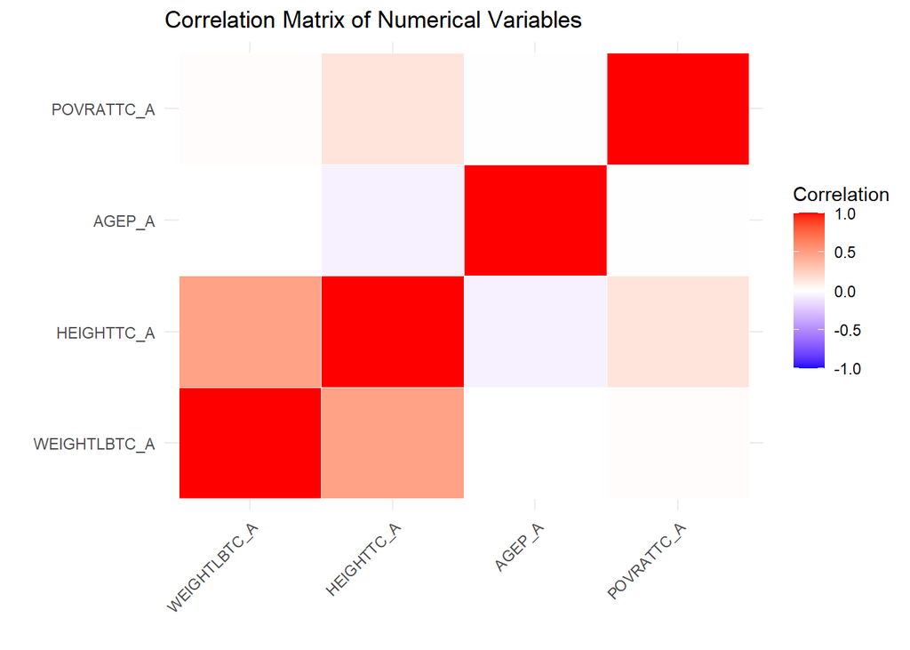

```r
cor_long <- melt(cor_matrix)

ggplot(cor_long, aes(x = Var1, y = Var2, fill = value)) +
  geom_tile(color = "white") +
  scale_fill_gradient2(
    low = "blue", high = "red", mid = "white",
    midpoint = 0, limit = c(-1, 1),
    name = "Correlation"
  ) +
  theme_minimal() +
  labs(
    title = "Correlation Matrix of Numerical Variables",
    x = "",
    y = ""
  ) +
  theme(axis.text.x = element_text(angle = 45, vjust = 1, hjust = 1))
```

## Association Analysis Between Categorical Variables

To identify potential redundancy or strong associations between categorical features, we computed **Cramér’s V** for all possible pairs of categorical variables in the dataset.

```r
cat_vars <- names(data)[sapply(data, is.factor)]
comb_list <- combn(cat_vars, 2, simplify = FALSE)

results <- lapply(comb_list, function(pair) {
  tab <- table(data[[pair[1]]], data[[pair[2]]])
  if (min(dim(tab)) > 1) {
    v <- suppressWarnings(CramerV(tab))
    return(data.frame(var1 = pair[1], var2 = pair[2], cramer_v = v))
  }
  return(NULL)
})
results_df <- do.call(rbind, results)
filtered_results <- subset(results_df, cramer_v > 0.7)
```

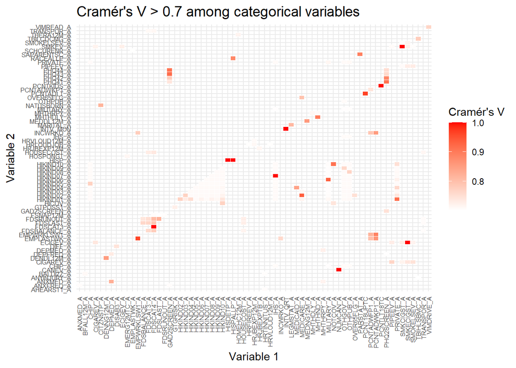

```r
ggplot(filtered_results, aes(x = var1, y = var2, fill = cramer_v)) +
  geom_tile(color = "white") +
  scale_fill_gradient(low = "white", high = "red") +
  theme_minimal() +
  labs(
    title = "Cramér's V > 0.7 among categorical variables",
    x = "Variable 1",
    y = "Variable 2",
    fill = "Cramér's V"
  ) +
  theme(
    axis.text.x = element_text(angle = 90, vjust = 0.5, hjust = 1, size = 6),
    axis.text.y = element_text(size = 6),
    plot.title = element_text(size = 14)
  )
```

### Example: Collinearity Among Ethnicity Variables

The dataset includes multiple variables capturing Hispanic ethnicity:

- `HISP_A`: High-level Hispanic ethnicity recode
- `HISPALLP_A`: Race/ethnicity combinations with Hispanic origin
- `HISDETP_A`: Detailed Hispanic origin categories

```r
# HISP_A vs HISPALLP_A
tab1 <- table(data$HISP_A, data$HISPALLP_A)
chi1 <- chisq.test(tab1)
print(chi1)
```

```
##
##  Pearson's Chi-squared test
##
## data:  tab1
## X-squared = 24190, df = 6, p-value < 2.2e-16
```

```r
cat("Cramér's V (HISP_A vs HISPALLP_A):", CramerV(tab1), "\n")
```

```
## Cramér's V (HISP_A vs HISPALLP_A): 1
```

```r
# HISP_A vs HISDETP_A
tab2 <- table(data$HISP_A, data$HISDETP_A)
chi2 <- chisq.test(tab2)
print(chi2)
```

```
##
##  Pearson's Chi-squared test
##
## data:  tab2
## X-squared = 24190, df = 3, p-value < 2.2e-16
```

```r
cat("Cramér's V (HISP_A vs HISDETP_A):", CramerV(tab2), "\n")
```

```
## Cramér's V (HISP_A vs HISDETP_A): 1
```

```r
threshold <- 0.7
highly_correlated <- results_df %>%
  filter(cramer_v > threshold) %>%
  arrange(desc(cramer_v))

to_remove <- c()
used <- c()

for (i in seq_len(nrow(highly_correlated))) {
  v1 <- highly_correlated$var1[i]
  v2 <- highly_correlated$var2[i]
  if (!(v1 %in% used) && !(v2 %in% used)) {
    to_remove <- c(to_remove, v2)
    used <- c(used, v2)
  }
}

data <- data[, !(names(data) %in% to_remove)]

cat("✅ Removed", length(to_remove), "highly collinear variables:\n")
```

```
## ✅ Removed 65 highly collinear variables:
```

```r
print(to_remove)
```

```
##  [1] "HISP_A"       "FDSCAT3_A"    "ECIGEV_A"     "SMKEV_A"      "CANEV_A"
##  [6] "INTV_MON"     "HIKIND07_A"   "PCNTKIDS_A"   "PCNTADLT_A"   "EMPLASTWK_A"
## [11] "HIKIND02_A"   "HIKIND06_A"   "PHQ43_A"      "HIKIND01_A"   "PHQ44_A"
## [16] "HIKIND10_A"   "PHQ41_A"      "MHTHDLY_A"    "SAPARENTSC_A" "EMPWRKLSW1_A"
## [21] "PHQ42_A"      "RACEALLP_A"   "MEDDL12M_A"   "INCWRKO_A"    "DENDL12M_A"
## [26] "HIKIND04_A"   "ANXMED_A"     "FDSRUNOUT_A"  "NATUSBORN_A"  "MARITAL_A"
## [31] "OVER65FLG_A"  "FDSLAST_A"    "FDSBALANCE_A" "TBILCDCMG_A"  "HIKIND05_A"
## [36] "HIKIND08_A"   "VIMREAD_A"    "CIGAREV_A"    "HIKIND09_A"   "GAD2SCREEN_A"
## [41] "DIFF_A"       "PCNTADWKP1_A" "HICOV_A"      "HOUSECOST_A"  "DEPFREQ_A"
## [46] "PIPEEV_A"     "GTPOSS1_A"    "DEPMED_A"     "SMOKELSEV_A"  "THERA12M_A"
## [51] "HIKIND03_A"   "PRIVATE_A"    "HRJBEXP12M_A" "HOSPONGT_A"   "TRANSPOR_A"
## [56] "BALDIZZ_A"    "MHTHRPY_A"    "IHS_A"        "OTHPUB_A"     "CHIP_A"
## [61] "AHEARST1_A"   "FSNAP12M_A"   "MILITARY_A"   "HRLOUDJOB_A"  "ANYINJURY_A"
```

## Handling Perfect Separation in Categorical Predictors

In classification tasks, **perfect separation** occurs when a level of a categorical predictor is associated exclusively with one class of the target variable. This can lead to unstable or non-identifiable models, especially in logistic regression.

To mitigate this issue, we implemented the following strategy:

1. Iterated through all categorical variables (excluding the target).
2. Built a contingency table between each variable and the target `has_diabetes`.
3. Identified factor levels that only occur in a single class (either “Yes” or “No”).
4. Removed all rows containing these levels from the dataset.
5. Dropped the unused levels to ensure clean factor encoding.

This ensures that the dataset does not contain levels that could cause convergence issues or inflated coefficients due to lack of variability across the target.

The following message was printed for each affected variable:

```r
target_var <- "has_diabetes"

for (v in names(data)) {
  if (v == target_var || !is.factor(data[[v]])) next
  if (nlevels(data[[v]]) <= 1) next

  tab <- table(data[[v]], data[[target_var]])
  problematic_levels <- apply(tab, 1, function(x) any(x == 0))

  if (any(problematic_levels)) {
    levels_to_drop <- names(problematic_levels[problematic_levels])
    cat(sprintf(" Variable '%s' - removing rows with levels causing perfect separation: %s\n",
                v, paste(levels_to_drop, collapse = ", ")))

    data <- data[!data[[v]] %in% levels_to_drop, ]

    data[[v]] <- droplevels(data[[v]])
  }
}
```

```
##  Variable 'SMKECIGST_A' - removing rows with levels causing perfect separation: 4
##  Variable 'SMKCIGST_A' - removing rows with levels causing perfect separation: 5
##  Variable 'BPLAST_A' - removing rows with levels causing perfect separation: 0, 5
##  Variable 'UPPOBJCT_A' - removing rows with levels causing perfect separation: unknown
##  Variable 'UPPSLFCR_A' - removing rows with levels causing perfect separation: unknown
##  Variable 'COGMEMDFF_A' - removing rows with levels causing perfect separation: unknown
##  Variable 'COMDIFF_A' - removing rows with levels causing perfect separation: unknown
##  Variable 'EQUIP_A' - removing rows with levels causing perfect separation: unknown
##  Variable 'HEARINGDF_A' - removing rows with levels causing perfect separation: unknown
##  Variable 'VISIONDF_A' - removing rows with levels causing perfect separation: unknown
##  Variable 'DEPEV_A' - removing rows with levels causing perfect separation: unknown
##  Variable 'HYPEV_A' - removing rows with levels causing perfect separation: unknown
```

```r
summary(data)
```

```
##  URBRRL   INCTCFLG_A IMPINCFLG_A   HISPALLP_A    DISAB3_A    CITZNSTP_A
##  1:7019   0:23649    0:18506     1      : 3713   1: 2268   1      :21352
##  2:5485   1:  177    1: 2187     2      :15550   2:21558   2      : 1514
##  3:7581              2: 3133     3      : 2727             unknown:  960
##  4:3741                          4      : 1234
##                                  5      :  173
##                                  6      :  176
##                                  unknown:  253
##    LEGMSTAT_A     PCNTADWFP1_A    FDSCAT4_A      SMKECIGST_A      SMKCIGST_A
##  1      :  381   0      :8749   1      :19338   1      : 1314   1      : 2029
##  2      : 3842   1      :8519   2      : 1394   2      : 2991   2      :  666
##  3      :10484   2      :4712   3      : 1129   3      :18760   3      : 5868
##  4      : 6057   3      : 710   4      :  927   unknown:  761   4      :14485
##  5      : 2098   5      :  17   unknown: 1038                   unknown:  778
##  unknown:  964   6      :  90
##                  unknown:1029
##  BMICAT_A  WEIGHTLBTC_A      HEIGHTTC_A     URGNT12MTC_A    EMERG12MTC_A
##  1: 234   Min.   : 45.36   Min.   :1.499   0      :16263   0      :18695
##  2:7188   1st Qu.: 68.04   1st Qu.:1.626   1      : 4103   1      : 3227
##  3:8483   Median : 79.38   Median :1.676   2      : 1938   2      : 1127
##  4:7921   Mean   : 81.06   Mean   :1.693   3      :  674   3      :  308
##           3rd Qu.: 92.53   3rd Qu.:1.778   4      :  257   4      :  289
##           Max.   :135.62   Max.   :1.930   5      :  405   unknown:  180
##                                            unknown:  186
##  PCNT18UPTC PCNTLT18TC  PHQ2SCREEN_A      NOTCOV_A        OTHGOV_A
##  1: 8625    0:17479    1      : 1585   1      : 1650   1      :   54
##  2:11546    1: 2690    2      :21598   2      :22117   3      :23697
##  3: 3655    2: 2330    unknown:  643   unknown:   59   unknown:   75
##             3: 1327
##
##
##
##    MEDICAID_A      MEDICARE_A       EDUCP_A       PARSTAT_A     MLTFAMFLG_A
##  1      : 3213   1      : 7747   4      :5614   1      : 5410   1:  535
##  2      :   53   2      :   21   8      :5503   2      :  774   2:23291
##  3      :20513   3      :15995   5      :3621   3      :17479
##  unknown:   47   unknown:   63   9      :2461   unknown:  163
##                                  7      :2263
##                                  1      :1573
##                                  (Other):2791
```

[output cut: 169 more lines]

```
##  1      : 1357   1      : 7748   1: 8772   1      :10313   1      :4862
##  2      :22424   2      :16041   2:15054   2      :12427   2      :8139
##  unknown:   45   unknown:   37             3      :  859   3      :7082
##                                            4      :  182   4      :2909
##                                            unknown:   45   5      : 824
##                                                            unknown:  10
##
##    POVRATTC_A     has_diabetes
##  Min.   : 0.000   No :21173
##  1st Qu.: 1.780   Yes: 2653
##  Median : 3.250
##  Mean   : 3.742
##  3rd Qu.: 5.180
##  Max.   :10.990
##
```

```r
dataset_dimensions <- dim(data)
num_rows <- dataset_dimensions[1]
num_cols <- dataset_dimensions[2]

na_counts <- colSums(is.na(data))
num_columns_with_na <- sum(na_counts > 0)
num_columns_complete <- sum(na_counts == 0)

cat("The dataset contains", num_rows, "rows and", num_cols, "columns.\n")
```

```
## The dataset contains 23826 rows and 128 columns.
```

```r
cat(num_columns_with_na, "columns contain at least one missing value,\n")
```

```
## 0 columns contain at least one missing value,
```

## Exploratory Data Analysis: Numeric Variables by Diabetes Status

We explored the distribution of key numeric predictors stratified by diabetes status (`has_diabetes`). Each histogram shows how the variable is distributed among respondents with and without a prior diagnosis of diabetes.

### Histograms Overview

- **Age (`AGEP_A`)**: This highlights **age as a strong predictive factor**, with increasing prevalence in older adults.
- **Weight (`WEIGHTLBTC_A`)**: Diabetic individuals tend to have **higher body weights**, confirming a known clinical link between body mass and diabetes risk. The distribution is shifted rightward for the “Yes” group.
- **Height (`HEIGHTTC_A`)**: No clear difference is seen in height distribution between groups, suggesting **height may not be an important predictor** in this context.
- **Poverty Ratio (`POVRATTC_A`)**: Diabetic individuals are more represented in the **lower poverty ratio** range, indicating a potential socioeconomic disparity. This may reflect limited access to healthcare or healthy lifestyles among economically disadvantaged groups.

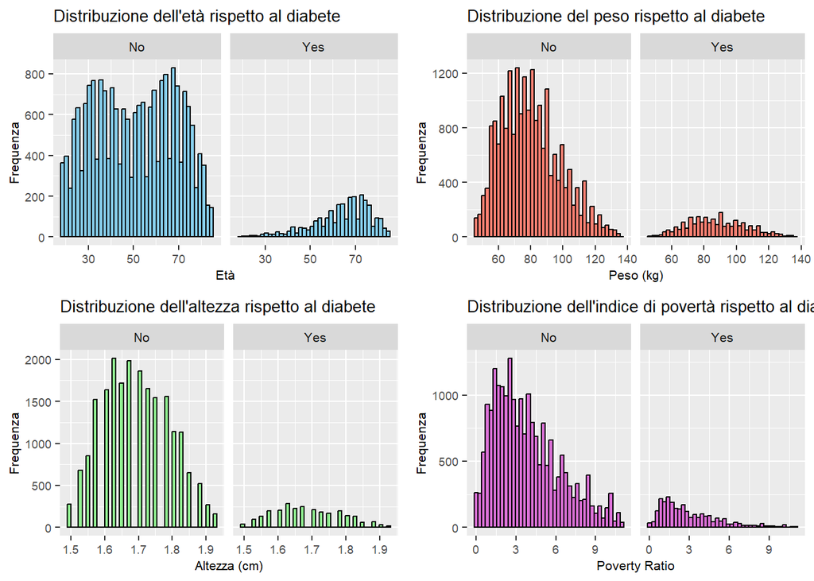

```r
small_text_theme <- theme(
  plot.title = element_text(size = 10),
  axis.title = element_text(size = 8),
  axis.text = element_text(size = 7),
  strip.text = element_text(size = 8)
)

p1 <- ggplot(data, aes(x = AGEP_A)) +
  geom_histogram(bins = 40, fill = "skyblue", color = "black") +
  facet_wrap(~has_diabetes) +
  ggtitle("Distribuzione dell'età rispetto al diabete") +
  xlab("Età") + ylab("Frequenza") +
  small_text_theme

p2 <- ggplot(data, aes(x = WEIGHTLBTC_A)) +
  geom_histogram(bins = 40, fill = "salmon", color = "black") +
  facet_wrap(~has_diabetes) +
  ggtitle("Distribuzione del peso rispetto al diabete") +
  xlab("Peso (kg)") + ylab("Frequenza") +
  small_text_theme

p3 <- ggplot(data, aes(x = HEIGHTTC_A)) +
  geom_histogram(bins = 40, fill = "lightgreen", color = "black") +
  facet_wrap(~has_diabetes) +
  ggtitle("Distribuzione dell'altezza rispetto al diabete") +
  xlab("Altezza (cm)") + ylab("Frequenza") +
  small_text_theme

p4 <- ggplot(data, aes(x = POVRATTC_A)) +
  geom_histogram(bins = 40, fill = "orchid", color = "black") +
  facet_wrap(~has_diabetes) +
  ggtitle("Distribuzione dell'indice di povertà rispetto al diabete") +
  xlab("Poverty Ratio") + ylab("Frequenza") +
  small_text_theme

grid.arrange(p1, p2, p3, p4, ncol = 2)
```

## Log Transformation of Numeric Variables

To improve the distributional properties of key numeric variables, we applied a **logarithmic transformation** using `log(x + 1)`. This helps to:

- Reduce skewness
- Compress extreme values (outliers)
- Facilitate model assumptions such as normality and homoscedasticity

### Variables Transformed

- `WEIGHTLBTC_A`: Weight in kilograms
- `POVRATTC_A`: Poverty ratio (family income relative to the poverty threshold)

We added two new variables to the dataset:

- `WEIGHTLBTC_A_log`
- `POVRATTC_A_log`

```r
data <- data %>%
  mutate(
    WEIGHTLBTC_A_log = log(WEIGHTLBTC_A + 1),
    POVRATTC_A_log = log(POVRATTC_A + 1)
  )

summary(data$WEIGHTLBTC_A_log)
```

```
##    Min. 1st Qu.  Median    Mean 3rd Qu.    Max.
##   3.836   4.235   4.387   4.383   4.538   4.917
```

```r
summary(data$POVRATTC_A_log)
```

```
##    Min. 1st Qu.  Median    Mean 3rd Qu.    Max.
##   0.000   1.022   1.447   1.416   1.821   2.484
```

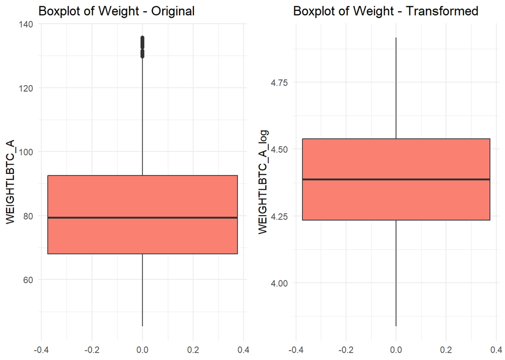

```r
make_boxplot_side <- function(data, var_orig, var_transf, label, color) {

  p1 <- ggplot(data, aes(y = .data[[var_orig]])) +
    geom_boxplot(fill = color) +
    ggtitle(paste("Boxplot of", label, "- Original")) +
    theme_minimal()

  p2 <- ggplot(data, aes(y = .data[[var_transf]])) +
    geom_boxplot(fill = color) +
    ggtitle(paste("Boxplot of", label, "- Transformed")) +
    theme_minimal()

  grid.arrange(p1, p2, ncol = 2)
}

make_boxplot_side(data, "WEIGHTLBTC_A", "WEIGHTLBTC_A_log", "Weight", "salmon")
```

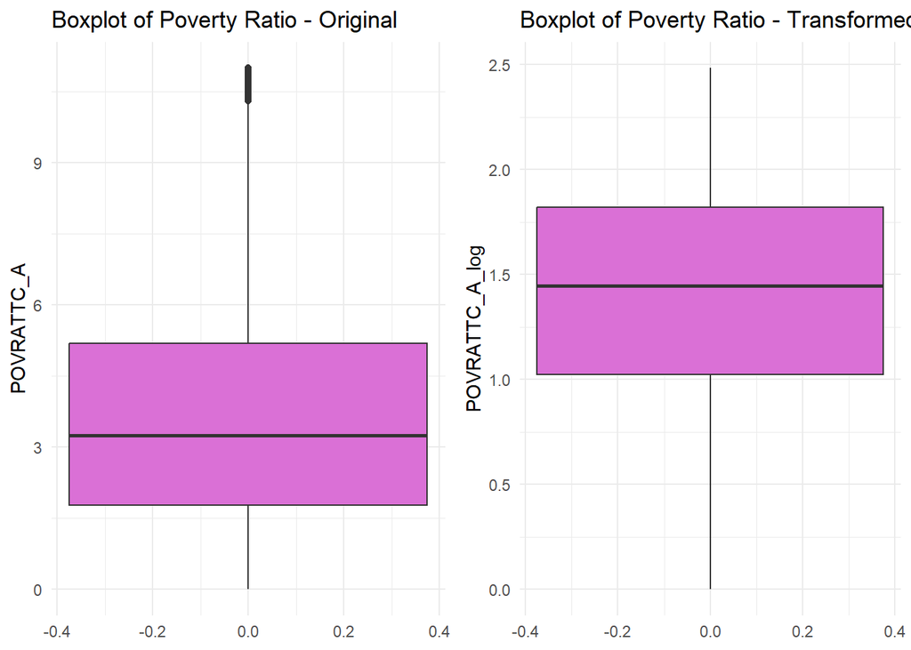

```r
make_boxplot_side(data, "POVRATTC_A", "POVRATTC_A_log", "Poverty Ratio", "orchid")
```

# Models

## Train/Test Split & Factor Level Alignment

```r
train_index <- createDataPartition(data$has_diabetes, p = 0.7, list = FALSE)
train_data <- data[train_index, ]
test_data  <- data[-train_index, ]

vars <- names(data)

for (v in vars) {
  if (is.factor(data[[v]])) {
    common_levels <- levels(data[[v]])
    train_data[[v]] <- factor(train_data[[v]], levels = common_levels)
    test_data[[v]]  <- factor(test_data[[v]],  levels = common_levels)
  }
}
```

## Lasso Model

Since the dataset is large and includes many variables, we apply **LASSO** to reduce dimensionality and select the most relevant predictors.

```r
x_train <- model.matrix(has_diabetes ~ . -1, data = train_data)
x_test  <- model.matrix(has_diabetes ~ . -1, data = test_data)

y_train_lasso <- as.numeric(train_data$has_diabetes) - 1
y_test_lasso  <- as.numeric(test_data$has_diabetes) - 1
```

```r
cv_lasso <- cv.glmnet(
  x_train, y_train_lasso,
  family = "binomial",
  alpha = 1,            # alpha = 1 = LASSO
  nfolds = 10           # 10-fold cross-validation
)
```

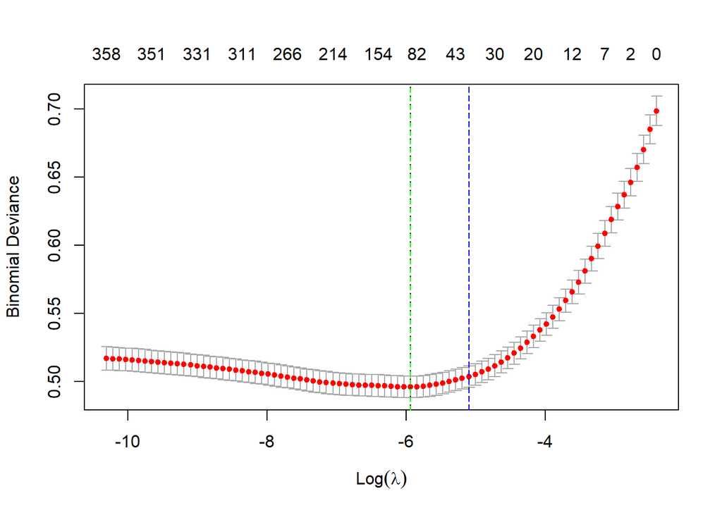

```r
plot(cv_lasso)
abline(v = log(cv_lasso$lambda.min), col = "green", lty = 2)
abline(v = log(cv_lasso$lambda.1se), col = "blue", lty = 2)
```

```r
evaluate_lasso_model <- function(pred_probs, y_true, model_name) {

  pred_probs <- as.numeric(pred_probs)

  roc_curve <- roc(y_true, pred_probs, quiet = TRUE)

  coords_best <- coords(
    roc_curve,
    x = "best",
    best.method = "youden",
    ret = c("threshold", "sensitivity", "specificity", "accuracy")
  )

  best_thresh <- as.numeric(coords_best["threshold"])
  sensitivity <- as.numeric(coords_best["sensitivity"])
  specificity <- as.numeric(coords_best["specificity"])
  accuracy    <- as.numeric(coords_best["accuracy"])
  auc_val     <- as.numeric(auc(roc_curve))

  model_results <- data.frame(
    Model = model_name,
    AUC = auc_val,
    Best.threshold = best_thresh,
    Accuracy = accuracy,
    Sensitivity = sensitivity,
    Specificity = specificity,
    stringsAsFactors = FALSE
  )

  return(model_results)
}
```

### Model Comparison

The table below compares the performance of two LASSO models:

- **`LASSO_lambda.min`**: uses the value of `lambda` that minimizes the cross-validation error.
- **`LASSO_lambda.1se`**: uses the largest value of `lambda` within one standard error of the minimum. This usually leads to a **simpler model** with fewer selected variables.

Choosing the model with `lambda.1se` follows the principle of **parsimony**, which favors simpler models when performance is comparable. Therefore, in the rest of the analysis, we will proceed with **`LASSO_lambda.1se`**.

```r
pred_min  <- predict(cv_lasso, newx = x_test, s = cv_lasso$lambda.min,  type = "response")
pred_1se  <- predict(cv_lasso, newx = x_test, s = cv_lasso$lambda.1se,  type = "response")

res_min  <- evaluate_lasso_model(pred_min,  y_test_lasso, "LASSO_lambda.min")
res_1se  <- evaluate_lasso_model(pred_1se,  y_test_lasso, "LASSO_lambda.1se")

all_results <- rbind(res_min, res_1se) %>%
  arrange(desc(AUC))

print(all_results)
```

```
##              Model       AUC Best.threshold  Accuracy Sensitivity Specificity
## 1 LASSO_lambda.min 0.8602544     0.09682061 0.7390148   0.8591195   0.7239805
## 2 LASSO_lambda.1se 0.8582682     0.09989949 0.7290792   0.8603774   0.7126437
```

```r
# --- Confusion Matrix for LASSO_lambda.min ---
best_thresh_min <- res_min$Best.threshold
class_min <- factor(ifelse(pred_min > best_thresh_min, "Yes", "No"), levels = c("No", "Yes"))
actual_class <- factor(ifelse(y_test_lasso == 1, "Yes", "No"), levels = c("No", "Yes"))

conf_matrix_min <- table(Predicted = class_min, Actual = actual_class)
conf_matrix_min
```

```
##          Actual
## Predicted   No  Yes
##       No  4598  112
##       Yes 1753  683
```

```r
# --- Confusion Matrix for LASSO_lambda.1se ---
best_thresh_1se <- res_1se$Best.threshold
class_1se <- factor(ifelse(pred_1se > best_thresh_1se, "Yes", "No"), levels = c("No", "Yes"))

conf_matrix_1se <- table(Predicted = class_1se, Actual = actual_class)
conf_matrix_1se
```

```
##          Actual
## Predicted   No  Yes
##       No  4526  111
##       Yes 1825  684
```

```r
lasso_coefs <- coef(cv_lasso, s = cv_lasso$lambda.1se)
num_nonzero <- sum(lasso_coefs != 0) - 1
cat("Number of selected variables:", num_nonzero, "\n")
```

```
## Number of selected variables: 35
```

### Feature Selection via LASSO

After applying LASSO regularization, we extracted the set of variables with non-zero coefficients. These are the predictors that contribute meaningfully to the model and will be used in the next phase: logistic regression modeling.

```r
lasso_coefs <- coef(cv_lasso, s = cv_lasso$lambda.1se)

coefs_df <- as.data.frame(as.matrix(lasso_coefs))
coefs_df$variable <- rownames(coefs_df)
colnames(coefs_df)[1] <- "coefficient"

selected_dummies <- coefs_df$variable[coefs_df$coefficient != 0 & coefs_df$variable != "(Intercept)"]

data_vars <- setdiff(names(data), "has_diabetes")

map_to_variable <- function(dummy, original_vars) {
  matched <- original_vars[sapply(original_vars, function(var) startsWith(dummy, var))]
  if (length(matched) > 0) return(matched[1]) else return(NA)
}

vars <- unique(na.omit(sapply(selected_dummies, map_to_variable, original_vars = data_vars)))
vars
```

```
##  [1] "HISPALLP_A"   "FDSCAT4_A"    "BMICAT_A"     "EMERG12MTC_A" "AGEP_A"
##  [6] "INCINTER_A"   "CEVOLUN1_A"   "AVISEXAM_A"   "ANXFREQ_A"    "EYEEX12M_A"
## [11] "SHTPNUEV_A"   "CHOLLAST_A"   "RXDG12M_A"    "RX12M_A"      "ACCSSINT_A"
## [16] "DENPREV_A"    "SOCSCLPAR_A"  "EQUIP_A"      "VISIONDF_A"   "VIMGLEV_A"
## [21] "HLTHCOND_A"   "CROHNSEV_A"   "ANXEV_A"      "STREV_A"      "MIEV_A"
## [26] "CHDEV_A"      "CHLEV_A"      "HYPEV_A"      "PHSTAT_A"     "WEIGHTLBTC_A"
## [31] "POVRATTC_A"
```

## Logistic Regression with Cross-Validation

```r
cross_validate_model <- function(formula_text, train_data, model_name = "Model_1", target = "has_diabetes", K = 5) {
  set.seed(123)
  folds <- createFolds(train_data[[target]], k = K, list = TRUE)
  formula_obj <- as.formula(formula_text)

  AIC_vals <- BIC_vals <- aucs <- accs <- specs <- senss <- thresholds <- c()
  vars <- all.vars(formula_obj)[-1]

  for (i in 1:K) {
    tryCatch({
      test_idx <- folds[[i]]
      train_cv <- train_data[-test_idx, ]
      test_cv  <- train_data[test_idx, ]

      for (v in vars) {
        if (v %in% names(train_data) && is.factor(train_data[[v]])) {
          lvls <- levels(train_data[[v]])
          train_cv[[v]] <- factor(train_cv[[v]], levels = lvls)
          test_cv[[v]]  <- factor(test_cv[[v]],  levels = lvls)

          # 🔍 Stampa livelli mancanti se presenti
          unseen_levels <- setdiff(levels(test_cv[[v]]), lvls)
          if (length(unseen_levels) > 0) {
            cat(sprintf(" Fold %d - Variable '%s' has unseen levels in test: %s\n",
                        i, v, paste(unseen_levels, collapse = ", ")))
          }
        }
      }

      model <- glm(formula_obj, data = train_cv, family = binomial)
      pred_probs <- predict(model, newdata = test_cv, type = "response")

      roc_curve <- suppressMessages(roc(test_cv[[target]], pred_probs))
      coords_best <- coords(roc_curve, "best", ret = c("threshold", "sensitivity", "specificity", "accuracy"))

      best_thresh <- as.numeric(coords_best["threshold"])
      sensitivity <- as.numeric(coords_best["sensitivity"])
      specificity <- as.numeric(coords_best["specificity"])
      accuracy <- as.numeric(coords_best["accuracy"])

      AIC_vals <- c(AIC_vals, AIC(model))
      BIC_vals <- c(BIC_vals, BIC(model))
      aucs <- c(aucs, as.numeric(auc(roc_curve)))
      thresholds <- c(thresholds, best_thresh)
      senss <- c(senss, sensitivity)
      specs <- c(specs, specificity)
      accs <- c(accs, accuracy)
    }, error = function(e) {
      cat("Error in fold", i, ":", e$message, "\n")
    })
  }

  final_model <- glm(formula_obj, data = train_data, family = binomial)

  results <- list(
    metrics = data.frame(
      Model = model_name,
      AIC = mean(AIC_vals, na.rm = TRUE),
      BIC = mean(BIC_vals, na.rm = TRUE),
      AUC = mean(aucs, na.rm = TRUE),
      Best.threshold = mean(thresholds, na.rm = TRUE),
      Accuracy = mean(accs, na.rm = TRUE),
      Specificity = mean(specs, na.rm = TRUE),
      Sensitivity = mean(senss, na.rm = TRUE),
      stringsAsFactors = FALSE
    ),
    model = final_model,
    best_threshold = mean(thresholds, na.rm = TRUE)
  )

  return(results)
}
```

```r
evaluate_on_test <- function(model, test_data, threshold, target = "has_diabetes") {
  vars <- all.vars(formula(model))[-1]


  pred_probs <- predict(model, newdata = test_data, type = "response")
  pred_class <- factor(ifelse(pred_probs > threshold, "Yes", "No"), levels = c("No", "Yes"))

  roc_curve <- suppressMessages(roc(test_data[[target]], pred_probs))
  auc_val <- as.numeric(auc(roc_curve))
  cm <- confusionMatrix(pred_class, test_data[[target]], positive = "Yes")

  return(list(
    AUC = auc_val,
    Accuracy = cm$overall["Accuracy"],
    Sensitivity = cm$byClass["Sensitivity"],
    Specificity = cm$byClass["Specificity"],
    ConfusionMatrix = cm$table
  ))
}
```

In this section, we fit a **logistic regression** model using the variables selected by **LASSO**. These variables were chosen based on their relevance to the target variable `has_diabetes`.

```r
vars <- c(
  "HISPALLP_A", "FDSCAT4_A", "BMICAT_A", "EMERG12MTC_A", "AGEP_A",
  "INCINTER_A", "CEVOLUN1_A", "AVISEXAM_A", "ANXFREQ_A", "EYEEX12M_A",
  "SHTPNUEV_A", "CHOLLAST_A", "RXDG12M_A", "RX12M_A", "ACCSSINT_A",
  "DENPREV_A", "SOCSCLPAR_A", "EQUIP_A", "VISIONDF_A", "VIMGLEV_A",
  "HLTHCOND_A", "CROHNSEV_A", "ANXEV_A", "STREV_A", "MIEV_A",
  "CHDEV_A", "CHLEV_A", "HYPEV_A", "PHSTAT_A", "WEIGHTLBTC_A", "POVRATTC_A"
)

formula_text <- paste("has_diabetes ~", paste(vars, collapse = " + "))

cv_results_model_full <- cross_validate_model(formula_text, train_data, model_name = "model_full")

final_test_eval_model_full <- evaluate_on_test(cv_results_model_full$model, test_data, threshold = cv_results_model_full$best_threshold)

print(cv_results_model_full$metrics)
```

```
##        Model      AIC      BIC       AUC Best.threshold  Accuracy Specificity
## 1 model_full 6605.521 7287.914 0.8709742     0.09530044 0.7475403   0.7333687
##   Sensitivity
## 1   0.8606107
```

```r
print(final_test_eval_model_full)
```

```
## $AUC
## [1] 0.861818
##
## $Accuracy
##  Accuracy
## 0.7497901
##
## $Sensitivity
## Sensitivity
##   0.8377358
##
## $Specificity
## Specificity
##   0.7387813
##
## $ConfusionMatrix
##           Reference
## Prediction   No  Yes
##        No  4692  129
##        Yes 1659  666
```

We now build a second version of the logistic regression model using **log-transformed versions** of selected numerical predictors. In particular, we replace the original `WEIGHTLBTC_A` and `POVRATTC_A` variables with their respective log-transformed counterparts:

- `WEIGHTLBTC_A_log`
- `POVRATTC_A_log`

The goal is to assess whether this transformation improves model calibration and predictive accuracy, especially in the presence of skewed distributions and outliers.

```r
vars <- c(
  "HISPALLP_A", "FDSCAT4_A", "BMICAT_A", "EMERG12MTC_A", "AGEP_A",
  "INCINTER_A", "CEVOLUN1_A", "AVISEXAM_A", "ANXFREQ_A", "EYEEX12M_A",
  "SHTPNUEV_A", "CHOLLAST_A", "RXDG12M_A", "RX12M_A", "ACCSSINT_A",
  "DENPREV_A", "SOCSCLPAR_A", "EQUIP_A", "VISIONDF_A", "VIMGLEV_A",
  "HLTHCOND_A", "CROHNSEV_A", "ANXEV_A", "STREV_A", "MIEV_A",
  "CHDEV_A", "CHLEV_A", "HYPEV_A", "PHSTAT_A", "WEIGHTLBTC_A_log", "POVRATTC_A_log"
)

formula_text <- paste("has_diabetes ~", paste(vars, collapse = " + "))

cv_results <- cross_validate_model(formula_text, train_data, model_name = "model_2")
model <- glm(formula = formula_text, data = train_data, family = binomial)
summary(model)
```

```
##
## Call:
## glm(formula = formula_text, family = binomial, data = train_data)
##
## Coefficients:
##                      Estimate Std. Error z value Pr(>|z|)
## (Intercept)         -8.722738   1.278264  -6.824 8.86e-12 ***
## HISPALLP_A2         -0.431236   0.092236  -4.675 2.93e-06 ***
## HISPALLP_A3         -0.172205   0.110511  -1.558 0.119171
## HISPALLP_A4          0.368110   0.156832   2.347 0.018917 *
## HISPALLP_A5          0.118235   0.303836   0.389 0.697173
## HISPALLP_A6         -0.901686   0.347261  -2.597 0.009416 **
## HISPALLP_Aunknown    0.265556   0.329261   0.807 0.419942
## FDSCAT4_A2           0.146614   0.116414   1.259 0.207881
## FDSCAT4_A3           0.050535   0.129931   0.389 0.697324
## FDSCAT4_A4           0.356639   0.137715   2.590 0.009606 **
## FDSCAT4_Aunknown    -0.079360   0.482148  -0.165 0.869261
## BMICAT_A2           -0.487581   0.395048  -1.234 0.217116
## BMICAT_A3           -0.238774   0.400551  -0.596 0.551100
## BMICAT_A4           -0.036307   0.413260  -0.088 0.929991
## EMERG12MTC_A1        0.115880   0.076956   1.506 0.132119
## EMERG12MTC_A2       -0.146826   0.120052  -1.223 0.221321
## EMERG12MTC_A3       -0.286977   0.208306  -1.378 0.168306
## EMERG12MTC_A4       -0.277152   0.213221  -1.300 0.193656
## EMERG12MTC_Aunknown  0.397855   0.590935   0.673 0.500780
## AGEP_A               0.013243   0.002816   4.703 2.57e-06 ***
## INCINTER_A2          0.284550   0.074941   3.797 0.000146 ***
## INCINTER_Aunknown    0.085097   0.225500   0.377 0.705898
## CEVOLUN1_A2          0.205251   0.076865   2.670 0.007579 **
## CEVOLUN1_Aunknown    0.374540   0.519741   0.721 0.471138
## AVISEXAM_A1          0.849120   0.142558   5.956 2.58e-09 ***
## AVISEXAM_A2          0.609014   0.150322   4.051 5.09e-05 ***
## AVISEXAM_A3          0.429866   0.179270   2.398 0.016491 *
## AVISEXAM_A4          0.237203   0.203268   1.167 0.243233
## AVISEXAM_A5         -0.128740   0.177157  -0.727 0.467409
## AVISEXAM_Aunknown    0.466162   0.292718   1.593 0.111266
## ANXFREQ_A2           0.206908   0.118148   1.751 0.079901 .
## ANXFREQ_A3           0.415950   0.126623   3.285 0.001020 **
## ANXFREQ_A4           0.309001   0.109883   2.812 0.004922 **
## ANXFREQ_A5           0.535811   0.114831   4.666 3.07e-06 ***
```

[output cut: 52 more lines]

```
## PHSTAT_A4            1.684412   0.160428  10.499  < 2e-16 ***
## PHSTAT_A5            1.866045   0.190342   9.804  < 2e-16 ***
## PHSTAT_Aunknown      1.865804   0.821006   2.273 0.023051 *
## WEIGHTLBTC_A_log     1.258948   0.223182   5.641 1.69e-08 ***
## POVRATTC_A_log      -0.215661   0.065586  -3.288 0.001008 **
## ---
## Signif. codes:  0 '***' 0.001 '**' 0.01 '*' 0.05 '.' 0.1 ' ' 1
##
## (Dispersion parameter for binomial family taken to be 1)
##
##     Null deviance: 11656.4  on 16679  degrees of freedom
## Residual deviance:  8051.1  on 16589  degrees of freedom
## AIC: 8233.1
##
## Number of Fisher Scoring iterations: 7
```

```r
final_test_eval <- evaluate_on_test(cv_results$model, test_data, threshold = cv_results$best_threshold)

print(cv_results$metrics)
```

```
##     Model      AIC      BIC       AUC Best.threshold  Accuracy Specificity
## 1 model_2 6601.641 7284.034 0.8711782     0.09762635 0.7517957   0.7386301
##   Sensitivity
## 1   0.8568501
```

```r
print(final_test_eval)
```

```
## $AUC
## [1] 0.8622944
##
## $Accuracy
##  Accuracy
## 0.7531486
##
## $Sensitivity
## Sensitivity
##   0.8314465
##
## $Specificity
## Specificity
##   0.7433475
##
## $ConfusionMatrix
##           Reference
## Prediction   No  Yes
##        No  4721  134
##        Yes 1630  661
```

After a thorough analysis and multiple modeling iterations, the **best-performing model**—in terms of predictive accuracy and simplicity—is the one using a **reduced set of selected variables**.

### Why these variables were selected

The selected variables are rooted in both clinical knowledge and socioeconomic context. Below is an explanation of each variable and why it plays an important role in predicting diabetes risk:

- **HISPALLP_A – Hispanic origin and race group**  
  This variable distinguishes between ethnic groups such as:
  - Hispanic
  - Non-Hispanic White
  - Non-Hispanic Black
  - Non-Hispanic Asian
  - American Indian/Alaska Native (AIAN)
  - Mixed/Other races  
    Ethnic background is a strong predictor of diabetes risk due to differences in genetics, diet, lifestyle, and access to care. For example, Hispanic and Black populations in the U.S. face significantly higher risks of developing type 2 diabetes.
- **AGEP_A – Age**  
  Increasing age is directly linked with higher risk of diabetes. With age, insulin sensitivity tends to decline and metabolic function weakens, making older individuals more susceptible.
- **AVISEXAM_A – Time since last eye exam**  
  This is a proxy for healthcare behavior. The levels include:
  - Never
  - Within the past year
  - 1–2 years ago
  - 2–3 years ago
  - 3–5 years ago
  - 5+ years ago  
    Frequent eye exams could indicate greater health consciousness or existing complications such as diabetic retinopathy, which is common among diabetic patients.
- **CHDEV_A – Ever diagnosed with coronary heart disease**  
  Heart disease and diabetes share similar pathophysiological roots, including obesity, inflammation, and hypertension. A previous diagnosis of CHD strongly suggests metabolic stress.
- **CHLEV_A – Ever diagnosed with high cholesterol**  
  Elevated cholesterol is a core component of metabolic syndrome and often appears before diabetes onset.
- **HYPEV_A – Ever diagnosed with hypertension**  
  Like cholesterol, hypertension is both a risk factor and a common comorbidity in diabetic patients.
- **PHSTAT_A – General health status**  
  Self-rated health levels include:
  - Excellent
  - Very good
  - Good
  - Fair
  - Poor  
    Subjective health evaluations often reflect the presence of chronic conditions. Those reporting “fair” or “poor” health are significantly more likely to have underlying illnesses, including diabetes.
- **WEIGHTLBTC_A_log – Log-transformed weight**  
  Obesity is one of the strongest predictors of diabetes. Log transformation helps reduce skewness and normalize the distribution for regression modeling.
- **POVRATTC_A_log – Log-transformed poverty ratio**  
  Poverty impacts access to quality food, healthcare, and education. Lower income is strongly linked with higher prevalence and poorer management of diabetes. Log transformation again helps reduce skewness in the variable.

Together, these variables offer a meaningful and interpretable structure to capture both the biological and socioeconomic dimensions influencing diabetes risk.

```r
vars <- c(
  "HISPALLP_A", "AGEP_A", "AVISEXAM_A", "CHDEV_A", "CHLEV_A", "HYPEV_A", "PHSTAT_A", "WEIGHTLBTC_A_log", "POVRATTC_A_log"
)


formula_text <- paste("has_diabetes ~ ", paste(vars, collapse = " + "))

cv_results <- cross_validate_model(formula_text, train_data, model_name = "Logistic")
model <- glm(formula = formula_text, data = train_data, family = binomial)
summary(model)
```

```
##
## Call:
## glm(formula = formula_text, family = binomial, data = train_data)
##
## Coefficients:
##                     Estimate Std. Error z value Pr(>|z|)
## (Intercept)       -12.133172   0.699921 -17.335  < 2e-16 ***
## HISPALLP_A2        -0.429984   0.086883  -4.949 7.46e-07 ***
## HISPALLP_A3        -0.092560   0.105858  -0.874 0.381910
## HISPALLP_A4         0.388071   0.151561   2.560 0.010453 *
## HISPALLP_A5         0.059792   0.295430   0.202 0.839614
## HISPALLP_A6        -0.765099   0.338637  -2.259 0.023862 *
## HISPALLP_Aunknown   0.183279   0.320513   0.572 0.567436
## AGEP_A              0.024450   0.002305  10.606  < 2e-16 ***
## AVISEXAM_A1         1.225848   0.131713   9.307  < 2e-16 ***
## AVISEXAM_A2         0.719075   0.145283   4.949 7.44e-07 ***
## AVISEXAM_A3         0.490137   0.172993   2.833 0.004607 **
## AVISEXAM_A4         0.302119   0.196373   1.538 0.123928
## AVISEXAM_A5        -0.155039   0.171671  -0.903 0.366464
## AVISEXAM_Aunknown   0.601045   0.192422   3.124 0.001787 **
## CHDEV_A2           -0.400907   0.083767  -4.786 1.70e-06 ***
## CHDEV_Aunknown     -0.700393   0.475345  -1.473 0.140632
## CHLEV_A2           -0.790138   0.061509 -12.846  < 2e-16 ***
## CHLEV_Aunknown     -0.107178   0.528551  -0.203 0.839309
## HYPEV_A2           -0.758245   0.067075 -11.304  < 2e-16 ***
## PHSTAT_A2           0.765189   0.154600   4.949 7.44e-07 ***
## PHSTAT_A3           1.491601   0.149363   9.986  < 2e-16 ***
## PHSTAT_A4           1.998467   0.154768  12.913  < 2e-16 ***
## PHSTAT_A5           2.306467   0.176504  13.068  < 2e-16 ***
## PHSTAT_Aunknown     2.646390   0.743103   3.561 0.000369 ***
## WEIGHTLBTC_A_log    1.898386   0.141741  13.393  < 2e-16 ***
## POVRATTC_A_log     -0.383455   0.056501  -6.787 1.15e-11 ***
## ---
## Signif. codes:  0 '***' 0.001 '**' 0.01 '*' 0.05 '.' 0.1 ' ' 1
##
## (Dispersion parameter for binomial family taken to be 1)
##
##     Null deviance: 11656.4  on 16679  degrees of freedom
## Residual deviance:  8494.8  on 16654  degrees of freedom
## AIC: 8546.8
##
## Number of Fisher Scoring iterations: 7
```

```r
final_test_eval <- evaluate_on_test(cv_results$model, test_data, threshold = cv_results$best_threshold)

print(cv_results$metrics)
```

```
##      Model     AIC      BIC       AUC Best.threshold  Accuracy Specificity
## 1 Logistic 6842.15 7037.119 0.8589643      0.1057203 0.7582136   0.7490224
##   Sensitivity
## 1   0.8315451
```

```r
print(final_test_eval)
```

```
## $AUC
## [1] 0.8473935
##
## $Accuracy
##  Accuracy
## 0.7560873
##
## $Sensitivity
## Sensitivity
##   0.7974843
##
## $Specificity
## Specificity
##   0.7509054
##
## $ConfusionMatrix
##           Reference
## Prediction   No  Yes
##        No  4769  161
##        Yes 1582  634
```

### Interpretation of Logistic Regression Coefficients

The logistic regression output provides insights into how each variable affects the likelihood of being diagnosed with diabetes. Here’s a summary of the key findings:

#### Intercept

- **(Intercept): -12.13**  
  This is the baseline log-odds of diabetes when all predictors are at zero. It’s not directly interpretable on its own but is used as a reference.

#### Demographics

- **AGEP_A: +0.024**  
  Each additional year of age increases the log-odds of having diabetes. Older individuals are more at risk.
- **HISPALLP_A**
  - **HISPALLP_A2 (Non-Hispanic White): -0.43**  
    Lower risk compared to the reference group (Hispanic).
  - **HISPALLP_A4 (Non-Hispanic Asian): +0.39**  
    Slightly increased risk compared to Hispanics.
  - **HISPALLP_A6 (Non-Hispanic AIAN + other): -0.77**  
    Significantly decreased risk, though based on a smaller group.
  - Other groups were not significant.

#### Health Behavior and History

- **AVISEXAM_A (Time since last eye exam)**  
  (Reference: never had an exam)
  - **AVISEXAM_A1 (within the past year): +1.23**  
    Strongly associated with higher diabetes probability – may reflect diagnosis and follow-up.
  - **AVISEXAM_A2/3/4 (1–5 years ago): +0.30 to +0.72**  
    Still positively associated but less strongly.
  - **AVISEXAM_A5 (5+ years): -0.16**  
    Negative, possibly due to lack of health monitoring.
  - **Unknown: +0.60**  
    Surprisingly positive, potentially reflecting uncertainty in healthcare access.
- **CHDEV_A2 (No CHD): -0.40**  
  People who report no coronary heart disease have significantly lower diabetes risk (logical link between metabolic diseases).
- **CHLEV_A2 (No high cholesterol): -0.79**  
  Again, absence of this condition is associated with reduced diabetes risk.
- **HYPEV_A2 (No hypertension): -0.76**  
  Strong negative predictor—hypertension and diabetes often co-occur.

#### Subjective Health Status

- **PHSTAT_A (General health, reference: Excellent)**  
  Higher values (worse self-perceived health) are associated with increased diabetes risk:
  - **Very Good: +0.77**
  - **Good: +1.49**
  - **Fair: +2.00**
  - **Poor: +2.31**
  - **Unknown: +2.65**

  There’s a clear dose-response trend: the worse the self-rated health, the more likely the person has diabetes.

#### Anthropometric and Socioeconomic Factors

- **WEIGHTLBTC_A_log: +1.90**  
  Strong positive predictor. Higher (log-transformed) weight greatly increases diabetes risk. This aligns with well-established links between obesity and diabetes.
- **POVRATTC_A_log: -0.38**  
  A higher poverty ratio (i.e., being above the poverty line) **reduces** the probability of diabetes. Poverty is a known risk factor due to barriers in accessing healthy food and healthcare.

### Summary

- **Positive coefficients** (e.g., poor health, recent eye exam, age, weight) indicate higher risk of diabetes.
- **Negative coefficients** (e.g., no hypertension/cholesterol, higher income) indicate protective factors.
- The most influential predictors are **self-rated health**, **weight**, and **access to healthcare** (eye exams, diagnosis history).

## LDA

```r
cross_validate_lda <- function(formula_text, train_data, model_name = "LDA_Model", target = "has_diabetes", K = 5) {
  set.seed(123)
  folds <- createFolds(train_data[[target]], k = K, list = TRUE)
  formula_obj <- as.formula(formula_text)

  aucs <- accs <- specs <- senss <- thresholds <- c()
  vars <- all.vars(formula_obj)[-1]

  for (i in 1:K) {
    tryCatch({
      test_idx <- folds[[i]]
      train_cv <- train_data[-test_idx, ]
      test_cv  <- train_data[test_idx, ]

      for (v in vars) {
        if (v %in% names(train_data) && is.factor(train_data[[v]])) {
          lvls <- levels(train_data[[v]])
          train_cv[[v]] <- factor(train_cv[[v]], levels = lvls)
          test_cv[[v]]  <- factor(test_cv[[v]],  levels = lvls)
        }
      }

      model <- lda(formula_obj, data = train_cv)
      pred_probs <- predict(model, newdata = test_cv)$posterior[, "Yes"]

      roc_curve <- suppressMessages(roc(test_cv[[target]], pred_probs))
      coords_best <- coords(roc_curve, "best", ret = c("threshold", "sensitivity", "specificity", "accuracy"))

      best_thresh <- as.numeric(coords_best["threshold"])
      sensitivity <- as.numeric(coords_best["sensitivity"])
      specificity <- as.numeric(coords_best["specificity"])
      accuracy <- as.numeric(coords_best["accuracy"])

      aucs <- c(aucs, as.numeric(auc(roc_curve)))
      thresholds <- c(thresholds, best_thresh)
      senss <- c(senss, sensitivity)
      specs <- c(specs, specificity)
      accs <- c(accs, accuracy)
    }, error = function(e) {
      cat("Error in fold", i, ":", e$message, "\n")
    })
  }

  final_model <- lda(formula_obj, data = train_data)

  results <- list(
    metrics = data.frame(
      Model = model_name,
      AUC = mean(aucs, na.rm = TRUE),
      Best.threshold = mean(thresholds, na.rm = TRUE),
      Accuracy = mean(accs, na.rm = TRUE),
      Specificity = mean(specs, na.rm = TRUE),
      Sensitivity = mean(senss, na.rm = TRUE),
      stringsAsFactors = FALSE
    ),
    model = final_model,
    best_threshold = mean(thresholds, na.rm = TRUE)
  )

  return(results)
}
```

```r
evaluate_on_test_lda <- function(model, test_data, threshold, target = "has_diabetes") {
  vars <- all.vars(model$call)[-1]

  pred_probs <- predict(model, newdata = test_data)$posterior[, "Yes"]
  pred_class <- factor(ifelse(pred_probs > threshold, "Yes", "No"), levels = c("No", "Yes"))

  roc_curve <- suppressMessages(roc(test_data[[target]], pred_probs))
  auc_val <- as.numeric(auc(roc_curve))
  cm <- confusionMatrix(pred_class, test_data[[target]], positive = "Yes")

  return(list(
    AUC = auc_val,
    Accuracy = cm$overall["Accuracy"],
    Sensitivity = cm$byClass["Sensitivity"],
    Specificity = cm$byClass["Specificity"],
    ConfusionMatrix = cm$table
  ))
}
```

```r
formula_text_lda <- paste("has_diabetes ~", paste(vars, collapse = " + "))

formula_text <- paste("has_diabetes ~", paste(vars, collapse = " + "))

cv_results_lda <- cross_validate_lda(formula_text, train_data, model_name = "LDA")
final_test_eval_lda <- evaluate_on_test_lda(cv_results_lda$model, test_data, threshold = cv_results_lda$best_threshold)

print(cv_results_lda$metrics)
```

```
##   Model      AUC Best.threshold  Accuracy Specificity Sensitivity
## 1   LDA 0.850917     0.08224123 0.7348961   0.7212952   0.8433643
```

```r
print(final_test_eval_lda)
```

```
## $AUC
## [1] 0.8380716
##
## $Accuracy
##  Accuracy
## 0.7342569
##
## $Sensitivity
## Sensitivity
##   0.7987421
##
## $Specificity
## Specificity
##   0.7261849
##
## $ConfusionMatrix
##           Reference
## Prediction   No  Yes
##        No  4612  160
##        Yes 1739  635
```

## Naive Bayes

```r
cross_validate_nb <- function(formula_text, train_data, model_name = "NaiveBayes_Model", target = "has_diabetes", K = 5) {
  set.seed(123)
  folds <- createFolds(train_data[[target]], k = K, list = TRUE)
  formula_obj <- as.formula(formula_text)

  aucs <- accs <- specs <- senss <- thresholds <- c()
  vars <- all.vars(formula_obj)[-1]

  for (i in 1:K) {
    tryCatch({
      test_idx <- folds[[i]]
      train_cv <- train_data[-test_idx, ]
      test_cv  <- train_data[test_idx, ]

      for (v in vars) {
        if (v %in% names(train_data) && is.factor(train_data[[v]])) {
          lvls <- levels(train_data[[v]])
          train_cv[[v]] <- factor(train_cv[[v]], levels = lvls)
          test_cv[[v]]  <- factor(test_cv[[v]],  levels = lvls)
        }
      }

      model <- naiveBayes(formula_obj, data = train_cv)
      pred_probs <- predict(model, newdata = test_cv, type = "raw")[, "Yes"]

      roc_curve <- suppressMessages(roc(test_cv[[target]], pred_probs))
      coords_best <- coords(roc_curve, "best", ret = c("threshold", "sensitivity", "specificity", "accuracy"))

      best_thresh <- as.numeric(coords_best["threshold"])
      sensitivity <- as.numeric(coords_best["sensitivity"])
      specificity <- as.numeric(coords_best["specificity"])
      accuracy <- as.numeric(coords_best["accuracy"])

      aucs <- c(aucs, as.numeric(auc(roc_curve)))
      thresholds <- c(thresholds, best_thresh)
      senss <- c(senss, sensitivity)
      specs <- c(specs, specificity)
      accs <- c(accs, accuracy)
    }, error = function(e) {
      cat("Error in fold", i, ":", e$message, "\n")
    })
  }

  final_model <- naiveBayes(formula_obj, data = train_data)

  results <- list(
    metrics = data.frame(
      Model = model_name,
      AUC = mean(aucs, na.rm = TRUE),
      Best.threshold = mean(thresholds, na.rm = TRUE),
      Accuracy = mean(accs, na.rm = TRUE),
      Specificity = mean(specs, na.rm = TRUE),
      Sensitivity = mean(senss, na.rm = TRUE),
      stringsAsFactors = FALSE
    ),
    model = final_model,
    best_threshold = mean(thresholds, na.rm = TRUE)
  )

  return(results)
}
```

```r
evaluate_on_test_nb <- function(model, test_data, threshold, target = "has_diabetes") {
  library(pROC)
  library(caret)

  pred_probs <- predict(model, newdata = test_data, type = "raw")[, "Yes"]
  pred_class <- factor(ifelse(pred_probs > threshold, "Yes", "No"), levels = c("No", "Yes"))

  roc_curve <- suppressMessages(roc(test_data[[target]], pred_probs))
  auc_val <- as.numeric(auc(roc_curve))
  cm <- confusionMatrix(pred_class, test_data[[target]], positive = "Yes")

  return(list(
    AUC = auc_val,
    Accuracy = cm$overall["Accuracy"],
    Sensitivity = cm$byClass["Sensitivity"],
    Specificity = cm$byClass["Specificity"],
    ConfusionMatrix = cm$table
  ))
}
```

```r
formula_text_nb <- paste("has_diabetes ~", paste(vars, collapse = " + "))

cv_results_nb <- cross_validate_nb(formula_text_nb, train_data, model_name = "NaiveBayes")
final_test_eval_nb <- evaluate_on_test_nb(cv_results_nb$model, test_data, threshold = cv_results_nb$best_threshold)

print(cv_results_nb$metrics)
```

```
##        Model       AUC Best.threshold Accuracy Specificity Sensitivity
## 1 NaiveBayes 0.8526043      0.1166464 0.752339   0.7438278   0.8202374
```

```r
print(final_test_eval_nb)
```

```
## $AUC
## [1] 0.8384744
##
## $Accuracy
##  Accuracy
## 0.7482508
##
## $Sensitivity
## Sensitivity
##   0.7685535
##
## $Specificity
## Specificity
##   0.7457093
##
## $ConfusionMatrix
##           Reference
## Prediction   No  Yes
##        No  4736  184
##        Yes 1615  611
```

## KNN

```r
cross_validate_knn <- function(formula_text, train_data, model_name = "KNN_Model", target = "has_diabetes", K = 5, k_neighbors = 5) {
  set.seed(123)
  folds <- createFolds(train_data[[target]], k = K, list = TRUE)
  formula_obj <- as.formula(formula_text)
  vars <- all.vars(formula_obj)[-1]

  aucs <- c()
  accs <- c()
  specs <- c()
  senss <- c()
  thresholds <- c()

  for (i in 1:K) {
    tryCatch({
      test_idx <- folds[[i]]
      train_cv <- train_data[-test_idx, ]
      test_cv  <- train_data[test_idx, ]

      train_X <- train_cv[, vars]
      test_X  <- test_cv[, vars]
      train_Y <- train_cv[[target]]
      test_Y  <- test_cv[[target]]

      train_X <- as.data.frame(lapply(train_X, as.numeric))
      test_X  <- as.data.frame(lapply(test_X, as.numeric))

      pred_class <- knn(train = train_X, test = test_X, cl = train_Y, k = k_neighbors, prob = TRUE)
      pred_probs <- ifelse(attr(pred_class, "prob") >= 0.5, attr(pred_class, "prob"), 1 - attr(pred_class, "prob"))

      roc_curve <- suppressMessages(roc(test_Y, pred_probs))
      coords_best <- coords(roc_curve, "best", ret = c("threshold", "sensitivity", "specificity", "accuracy"), transpose = FALSE)

      aucs <- c(aucs, as.numeric(auc(roc_curve)))
      thresholds <- c(thresholds, as.numeric(coords_best[["threshold"]]))
      senss <- c(senss, as.numeric(coords_best[["sensitivity"]]))
      specs <- c(specs, as.numeric(coords_best[["specificity"]]))
      accs <- c(accs, as.numeric(coords_best[["accuracy"]]))
    }, error = function(e) {
      cat("Error in fold", i, ":", e$message, "\n")
    })
  }

  results <- list(
    metrics = data.frame(
      Model = model_name,
      AUC = mean(aucs, na.rm = TRUE),
      Best.threshold = mean(thresholds, na.rm = TRUE),
      Accuracy = mean(accs, na.rm = TRUE),
      Specificity = mean(specs, na.rm = TRUE),
      Sensitivity = mean(senss, na.rm = TRUE),
      stringsAsFactors = FALSE
    ),
    best_threshold = mean(thresholds, na.rm = TRUE),
    k = k_neighbors
  )

  return(results)
}
```

```r
evaluate_on_test_knn <- function(train_data, test_data, formula_text, threshold, k = 5, target = "has_diabetes") {
  formula_obj <- as.formula(formula_text)
  vars <- all.vars(formula_obj)[-1]

  train_X <- as.data.frame(lapply(train_data[, vars], as.numeric))
  test_X  <- as.data.frame(lapply(test_data[, vars], as.numeric))
  train_Y <- factor(train_data[[target]], levels = c("No", "Yes"))
  test_Y  <- factor(test_data[[target]], levels = c("No", "Yes"))

  pred_class <- knn(train = train_X, test = test_X, cl = train_Y, k = k, prob = TRUE)

  pred_probs <- ifelse(pred_class == "Yes", attr(pred_class, "prob"), 1 - attr(pred_class, "prob"))
  pred_final <- factor(ifelse(pred_probs >= threshold, "Yes", "No"), levels = c("No", "Yes"))

  roc_curve <- suppressMessages(roc(test_Y, pred_probs, levels = c("No", "Yes"), direction = "<"))
  auc_val <- as.numeric(auc(roc_curve))
  cm <- confusionMatrix(pred_final, test_Y, positive = "Yes")

  return(list(
    AUC = auc_val,
    Accuracy = cm$overall["Accuracy"],
    Sensitivity = cm$byClass["Sensitivity"],
    Specificity = cm$byClass["Specificity"],
    ConfusionMatrix = cm$table
  ))
}
```

```r
formula_text_knn <- paste("has_diabetes ~", paste(vars, collapse = " + "))

tuning_results <- lapply(1:20, function(k) {
  res <- cross_validate_knn(
    formula_text = formula_text_knn,
    train_data = train_data,
    model_name = paste0("KNN_k", k),
    k_neighbors = k
  )
  metrics <- res$metrics
  metrics$k <- k
  return(metrics)
})

tuning_metrics_df <- do.call(rbind, tuning_results)

print(tuning_metrics_df)
```

```
##      Model       AUC Best.threshold  Accuracy Specificity Sensitivity  k
## 1   KNN_k1 0.5000000            NaN 0.5000000   0.5000000   0.5000000  1
## 2   KNN_k2 0.3885065            NaN 0.5000000   0.5000000   0.5000000  2
## 3   KNN_k3 0.6676183      0.7583333 0.7692427   0.7983392   0.5371200  3
## 4   KNN_k4 0.7067918      0.8083333 0.7417246   0.7540805   0.6431441  4
## 5   KNN_k5 0.7276797      0.8933333 0.7153457   0.7167037   0.7044982  5
## 6   KNN_k6 0.7450945      0.8619048 0.6933432   0.6859384   0.7524114  6
## 7   KNN_k7 0.7580761      0.9089286 0.6717006   0.6567925   0.7906255  7
## 8   KNN_k8 0.7678196      0.8608333 0.6842308   0.6727204   0.7761456  8
## 9   KNN_k9 0.7772366      0.8633333 0.6987488   0.6910097   0.7604701  9
## 10 KNN_k10 0.7829709      0.8672727 0.7109872   0.7064642   0.7469640 10
## 11 KNN_k11 0.7869704      0.8613636 0.7264469   0.7251455   0.7367823 11
## 12 KNN_k12 0.7931133      0.8564103 0.7461614   0.7496952   0.7179839 12
## 13 KNN_k13 0.7964296      0.8516484 0.7363296   0.7354598   0.7432817 13
## 14 KNN_k14 0.7993753      0.8761905 0.7257178   0.7207517   0.7653494 14
## 15 KNN_k15 0.8009536      0.8712500 0.7302738   0.7270289   0.7562140 15
## 16 KNN_k16 0.8030858      0.8665441 0.7208018   0.7142776   0.7728980 16
## 17 KNN_k17 0.8049245      0.8686275 0.7262020   0.7212295   0.7658682 17
## 18 KNN_k18 0.8064742      0.8923977 0.7158903   0.7080733   0.7782468 18
## 19 KNN_k19 0.8089113      0.8815789 0.7225415   0.7158961   0.7755847 19
## 20 KNN_k20 0.8111279      0.8878571 0.6994039   0.6863490   0.8035504 20
```

```r
best_k_auc <- tuning_metrics_df$k[which.max(tuning_metrics_df$AUC)]
best_k_acc <- tuning_metrics_df$k[which.max(tuning_metrics_df$Accuracy)]

cat("Best k by AUC:", best_k_auc, "\n")
```

```
## Best k by AUC: 20
```

```r
cat("Best k by Accuracy:", best_k_acc, "\n")
```

```
## Best k by Accuracy: 3
```

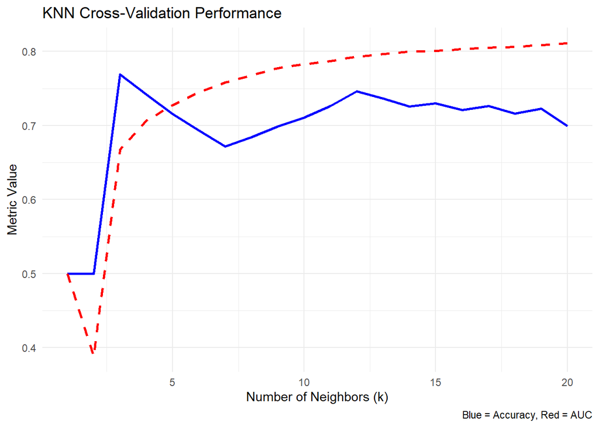

```r
ggplot(tuning_metrics_df, aes(x = k)) +
  geom_line(aes(y = Accuracy), color = "blue", linewidth = 1) +
  geom_line(aes(y = AUC), color = "red", linewidth = 1, linetype = "dashed") +
  labs(title = "KNN Cross-Validation Performance",
       x = "Number of Neighbors (k)",
       y = "Metric Value",
       caption = "Blue = Accuracy, Red = AUC") +
  theme_minimal()
```

```r
valid_metrics <- na.omit(tuning_metrics_df)

best_k <- valid_metrics$k[which.max(valid_metrics$AUC)]
cat("Miglior k selezionato:", best_k, "\n")
```

```
## Miglior k selezionato: 20
```

```r
cv_results_knn <- cross_validate_knn(
  formula_text = formula_text_knn,
  train_data = train_data,
  model_name = paste0("KNN_best_k", best_k),
  k_neighbors = best_k
)

final_test_eval_knn <- evaluate_on_test_knn(
  train_data = train_data,
  test_data = test_data,
  formula_text = formula_text_knn,
  threshold = cv_results_knn$best_threshold,
  k = best_k
)

print(cv_results_knn$metrics)
```

```
##          Model       AUC Best.threshold  Accuracy Specificity Sensitivity
## 1 KNN_best_k20 0.8111279      0.8878571 0.6994039    0.686349   0.8035504
```

```r
print(final_test_eval_knn)
```

```
## $AUC
## [1] 0.8060664
##
## $Accuracy
## Accuracy
## 0.888749
##
## $Sensitivity
## Sensitivity
##           0
##
## $Specificity
## Specificity
##           1
##
## $ConfusionMatrix
##           Reference
## Prediction   No  Yes
##        No  6351  795
##        Yes    0    0
```

## Model Comparison: Logistic Regression vs. LDA, Naive Bayes, and KNN

```r
logistic_metrics <- cv_results$metrics[, c("Model", "AUC", "Accuracy", "Sensitivity", "Specificity")]
lda_metrics      <- cv_results_lda$metrics[, c("Model", "AUC", "Accuracy", "Sensitivity", "Specificity")]
nb_metrics       <- cv_results_nb$metrics[, c("Model", "AUC", "Accuracy", "Sensitivity", "Specificity")]
knn_metrics       <- cv_results_knn$metrics[, c("Model", "AUC", "Accuracy", "Sensitivity", "Specificity")]

comparison_df <- rbind(logistic_metrics, lda_metrics, nb_metrics, knn_metrics)

print(comparison_df)
```

```
##          Model       AUC  Accuracy Sensitivity Specificity
## 1     Logistic 0.8589643 0.7582136   0.8315451   0.7490224
## 2          LDA 0.8509170 0.7348961   0.8433643   0.7212952
## 3   NaiveBayes 0.8526043 0.7523390   0.8202374   0.7438278
## 4 KNN_best_k20 0.8111279 0.6994039   0.8035504   0.6863490
```

```r
cat("\n--- Confusion Matrix: Logistic Regression ---\n")
```

```
##
## --- Confusion Matrix: Logistic Regression ---
```

```r
print(final_test_eval$ConfusionMatrix)
```

```
##           Reference
## Prediction   No  Yes
##        No  4769  161
##        Yes 1582  634
```

```r
cat("\n--- Confusion Matrix: LDA ---\n")
```

```
##
## --- Confusion Matrix: LDA ---
```

```r
print(final_test_eval_lda$ConfusionMatrix)
```

```
##           Reference
## Prediction   No  Yes
##        No  4612  160
##        Yes 1739  635
```

```r
cat("\n--- Confusion Matrix: Naive Bayes ---\n")
```

```
##
## --- Confusion Matrix: Naive Bayes ---
```

```r
print(final_test_eval_nb$ConfusionMatrix)
```

```
##           Reference
## Prediction   No  Yes
##        No  4736  184
##        Yes 1615  611
```

```r
cat("\n--- Confusion Matrix: KNN ---\n")
```

```
##
## --- Confusion Matrix: KNN ---
```

```r
print(final_test_eval_knn$ConfusionMatrix)
```

```
##           Reference
## Prediction   No  Yes
##        No  6351  795
##        Yes    0    0
```

## Ridge Regression

```r
x_train <- model.matrix(has_diabetes ~ . -1, data = train_data)
x_test  <- model.matrix(has_diabetes ~ . -1, data = test_data)

y_train_ridge <- as.numeric(train_data$has_diabetes) - 1
y_test_ridge  <- as.numeric(test_data$has_diabetes) - 1
```

```r
cv_ridge <- cv.glmnet(
  x_train, y_train_ridge,
  family = "binomial",
  alpha = 0,           # alpha = 0 = Ridge
  nfolds = 10
)
```

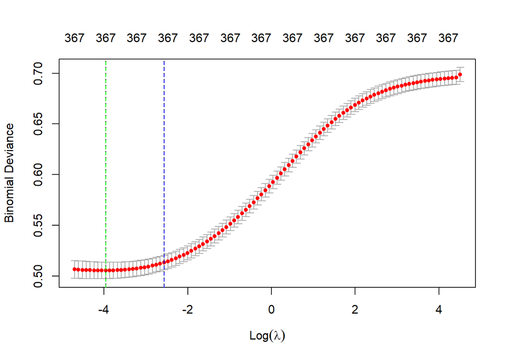

```r
plot(cv_ridge)
abline(v = log(cv_ridge$lambda.min), col = "green", lty = 2)
abline(v = log(cv_ridge$lambda.1se), col = "blue", lty = 2)
```

```r
pred_ridge_min  <- predict(cv_ridge, newx = x_test, s = cv_ridge$lambda.min, type = "response")
pred_ridge_1se  <- predict(cv_ridge, newx = x_test, s = cv_ridge$lambda.1se, type = "response")

res_ridge_min  <- evaluate_lasso_model(pred_ridge_min,  y_test_ridge, "Ridge_lambda.min")
res_ridge_1se  <- evaluate_lasso_model(pred_ridge_1se,  y_test_ridge, "Ridge_lambda.1se")

ridge_results <- rbind(res_ridge_min, res_ridge_1se) %>%
  arrange(desc(AUC))

print(ridge_results)
```

```
##              Model       AUC Best.threshold  Accuracy Sensitivity Specificity
## 1 Ridge_lambda.min 0.8555842     0.09576433 0.7472712   0.8603774   0.7331129
## 2 Ridge_lambda.1se 0.8535250     0.11320543 0.7538483   0.8389937   0.7431900
```

```r
# Per Ridge lambda.min
best_thresh_ridge_min <- res_ridge_min$Best.threshold
class_ridge_min <- factor(ifelse(pred_ridge_min > best_thresh_ridge_min, "Yes", "No"), levels = c("No", "Yes"))
actual_class_ridge <- factor(ifelse(y_test_ridge == 1, "Yes", "No"), levels = c("No", "Yes"))
conf_matrix_ridge_min <- table(Predicted = class_ridge_min, Actual = actual_class_ridge)
conf_matrix_ridge_min
```

```
##          Actual
## Predicted   No  Yes
##       No  4656  111
##       Yes 1695  684
```

```r
# Per Ridge lambda.1se
best_thresh_ridge_1se <- res_ridge_1se$Best.threshold
class_ridge_1se <- factor(ifelse(pred_ridge_1se > best_thresh_ridge_1se, "Yes", "No"), levels = c("No", "Yes"))
conf_matrix_ridge_1se <- table(Predicted = class_ridge_1se, Actual = actual_class_ridge)
conf_matrix_ridge_1se
```

```
##          Actual
## Predicted   No  Yes
##       No  4720  128
##       Yes 1631  667
```

```r
ridge_coefs <- coef(cv_ridge, s = cv_ridge$lambda.1se)
num_nonzero_ridge <- sum(ridge_coefs != 0) - 1
cat("Number of non-zero coefficients in Ridge (lambda.1se):", num_nonzero_ridge, "\n")
```

```
## Number of non-zero coefficients in Ridge (lambda.1se): 367
```

# Final Model Comparison & Conclusion

The table below summarizes the performance of all evaluated models on the diabetes classification task, ranked by AUC (Area Under the Curve):

```r
lasso_metrics <- rbind(res_min, res_1se)

ridge_metrics <- rbind(res_ridge_min, res_ridge_1se)
logistic_metrics_full <- cv_results_model_full$metrics[, c("Model", "AUC", "Accuracy", "Sensitivity", "Specificity")]
logistic_metrics <- cv_results$metrics[, c("Model", "AUC", "Accuracy", "Sensitivity", "Specificity")]
lda_metrics      <- cv_results_lda$metrics[, c("Model", "AUC", "Accuracy", "Sensitivity", "Specificity")]
nb_metrics       <- cv_results_nb$metrics[, c("Model", "AUC", "Accuracy", "Sensitivity", "Specificity")]
knn_metrics      <- cv_results_knn$metrics[, c("Model", "AUC", "Accuracy", "Sensitivity", "Specificity")]

all_model_metrics <- rbind(
  logistic_metrics_full,
  logistic_metrics,
  lda_metrics,
  nb_metrics,
  knn_metrics,
  lasso_metrics[, c("Model", "AUC", "Accuracy", "Sensitivity", "Specificity")],
  ridge_metrics[, c("Model", "AUC", "Accuracy", "Sensitivity", "Specificity")]
)

all_model_metrics <- all_model_metrics[order(-all_model_metrics$AUC), ]

print(all_model_metrics)
```

```
##              Model       AUC  Accuracy Sensitivity Specificity
## 1       model_full 0.8709742 0.7475403   0.8606107   0.7333687
## 6 LASSO_lambda.min 0.8602544 0.7390148   0.8591195   0.7239805
## 2         Logistic 0.8589643 0.7582136   0.8315451   0.7490224
## 7 LASSO_lambda.1se 0.8582682 0.7290792   0.8603774   0.7126437
## 8 Ridge_lambda.min 0.8555842 0.7472712   0.8603774   0.7331129
## 9 Ridge_lambda.1se 0.8535250 0.7538483   0.8389937   0.7431900
## 4       NaiveBayes 0.8526043 0.7523390   0.8202374   0.7438278
## 3              LDA 0.8509170 0.7348961   0.8433643   0.7212952
## 5     KNN_best_k20 0.8111279 0.6994039   0.8035504   0.6863490
```

GLM (Reduced) is the most balanced model, combining simplicity, interpretability, and solid performance across all metrics. LASSO models achieve comparable sensitivity and AUC to GLM, with the advantage of feature selection that improves model interpretability. Ridge performs very similarly to LASSO, slightly favoring stability over sparsity. Naive Bayes and LDA are competitive alternatives but slightly inferior in terms of AUC and specificity. KNN underperforms across all metrics, confirming its weakness in this high-dimensional, imbalanced classification task.